# VEGANScreener + metabolomics

Q1: Differences in the metabolome of vegans across different countries

**This script explores patterns in the metabolome profiles of vegans, with a focus on distinguishing between different countries of origin.**

The script is divided into two parts, based on how the metabolome datasets were integrated (see the preprocessing scripts for details). The first part analyzes the **sPCA dataset**, which is used for multivariate analysis, visualization, PERMANOVA testing, and the machine-learning models. The second part uses the **concatenated dataset** (LC-MS and NMR combined) for the univariate analysis: linear modelling, visualized through bipartite graphs.

The analysis is composed of the following main parts:

1. Global visualization — the first three components, color-coded by country.
2. PERMANOVA — how much of the variation can be explained by various external variables: dist(Metabolome) ~ sex + bmi + age + VS_total + veganDuration + country
3. Univariate analysis (feature-wise model) — linear modelling of each metabolite against various external variables: Metabolite ~ sex + bmi + age + VS_total + veganDuration + country

Individual means and p-values are obtained with the emmeans() function. A bipartite network is then constructed and color-coded according to the strongest association with the analyzed factor.

4. Random forest (RF) classification — the model is trained and validated by bootstrapping with 500 iterations, and used to distinguish country of origin. Two types of models are trained:
1. a model on the original sPCA dataset
2. a model on the sPCA dataset after regressing out the covariates.

# 1 Import

```r
metadata_df <- read.table(
  file = "../../data/preprocessed/metadata_preprocessed_v3.tsv",
  header = TRUE) %>%
  dplyr::filter(group=="VG")

lcms_df <- read.table(
  file = "../../data/preprocessed/metabolomics/lc_ms_preprocessed_INT_v3.tsv",
  check.names = FALSE)

nmr_df <- read.table(
  file = "../../data/preprocessed/metabolomics/nmr_preprocessed_INT_v3.tsv",
  check.names = FALSE)

spca_integrated_df <-  read.table(
  file = "../../data/preprocessed/metabolomics/spca_integrated_vegans_INT_v3.tsv",
  check.names = FALSE)
```

**Scaling** — when metadata columns are used as covariates, they need to be scaled so that each has a mean of 0 and a standard deviation of 1.

```r
metadata_scaled_df <- metadata_df
metadata_scaled_df[,-c(1,3,5,6,8)] <- apply(metadata_df[,-c(1,3,5,6,8)],2,scale)
metadata_scaled_df <- metadata_scaled_df %>%
  mutate(sex=as.factor(sex),
         country=as.factor(country),
         group=as.factor(group),
         diet_supplements=as.factor(diet_supplements))
```

# 2 Descriptive statistics

Summary of participant counts by diet group, country, and sex:

```r
metadata_df %>% dplyr::group_by(country,sex) %>% count()
```

```
# A tibble: 10 × 3
# Groups:   country, sex [10]
   country sex       n
   <chr>   <chr> <int>
 1 BE      F        54
 2 BE      M        28
 3 CH      F        23
 4 CH      M        20
 5 CZ      F        50
 6 CZ      M        41
 7 DE      F        51
 8 DE      M        47
 9 ES      F        28
10 ES      M        15
```

Basic plots showing the distribution of selected variables:

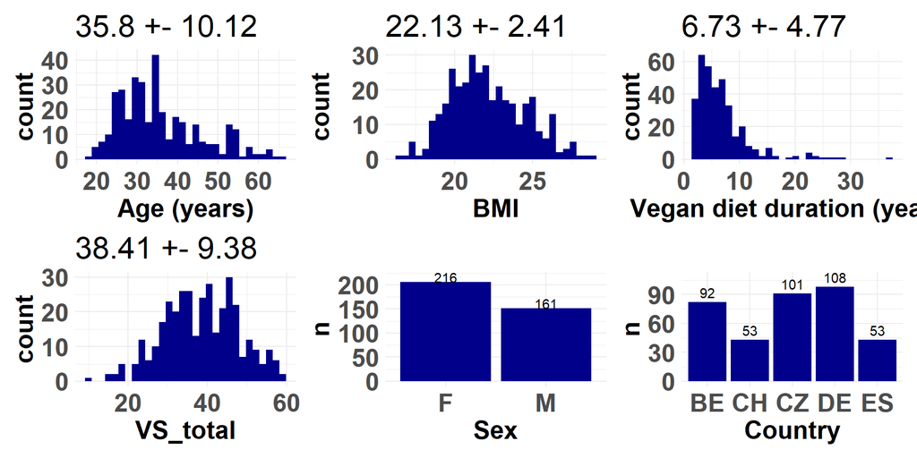

```r
plot_list <- list()
name <- c("Age (years)","BMI","Vegan diet duration (years)","VS_total")
i <- 1
for (col in c("age","bmi","vegan_duration","VS_total")){
  p <- ggplot(metadata_df) +
    geom_histogram(aes(x=!!sym(col)),fill="darkblue") +
    theme_minimal() +
    theme(axis.title = element_text(face="bold",size=20),
          axis.text=element_text(face="bold",size=20),
          title = element_text(face = "plain",size=20)) +
    xlab(name[i]) +
    ggtitle(paste(round(mean(metadata_df[,col],na.rm = TRUE),2),"+-", round(sd(metadata_df[,col],na.rm = TRUE),2)))

  plot_list[[length(plot_list)+1]] <- p
  i <- i + 1

}
i <- 1
name <- c("Sex","Country")
for (col in c("sex","country")){
  p <- ggplot(metadata_df) +
        theme_minimal() +
     theme(axis.title = element_text(face="bold",size=20),
          axis.text=element_text(face="bold",size=20)) +
    stat_count(aes(x=!!sym(col)),fill="darkblue") +
    xlab(name[i]) +
  geom_text(data=metadata_df %>%
              dplyr::group_by(!!sym(col)) %>% count() %>%
              dplyr::mutate(n=n+10), aes(x=!!sym(col),y=n,label=n))

  plot_list[[length(plot_list)+1]] <- p

  i <- i+1
}

wrap_plots(plot_list)
```

# 3 SPCA

The sPCA dataset was created by concatenating the LC-MS and NMR datasets and applying the mixOmics::spca() function. See the preprocessing script for details.

mixOmics::spca() performs **sparse Principal Component Analysis (sPCA)**, which works like regular PCA but adds a sparsity constraint so that only a subset of variables contributes to each component. The degree of sparsity is controlled by a penalization term, which makes the components easier to interpret because irrelevant or noisy variables are given loadings of zero.

## 3.1 Visualization

### 3.1.1 PCA

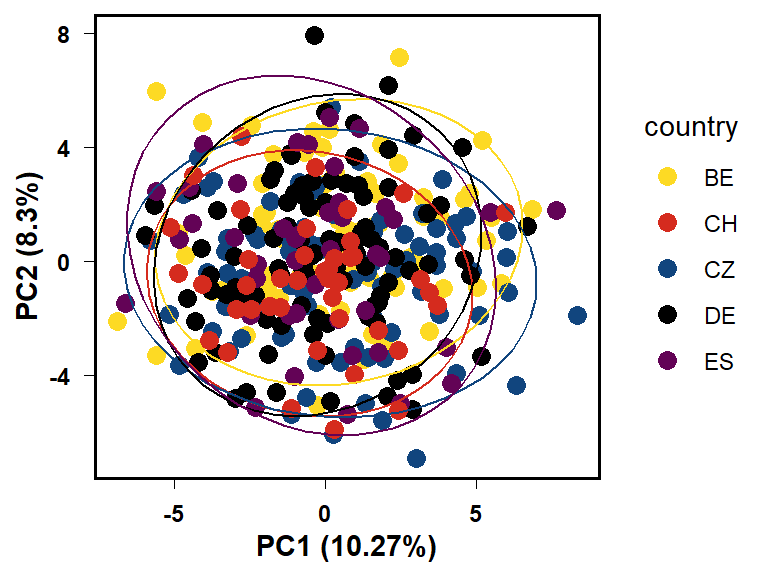

```r
spca_plot_df <- merge(
  spca_integrated_df %>% rownames_to_column("study_id"),
  metadata_df,by="study_id")

p <- pca_plot(spca_integrated_df,
              metadata_df,
              color_col = "country",
              perform_pca = FALSE)

p <- ggtheme(p)

p
```

```r
p_pca <- list()
p_pca[[1]] <- p
```

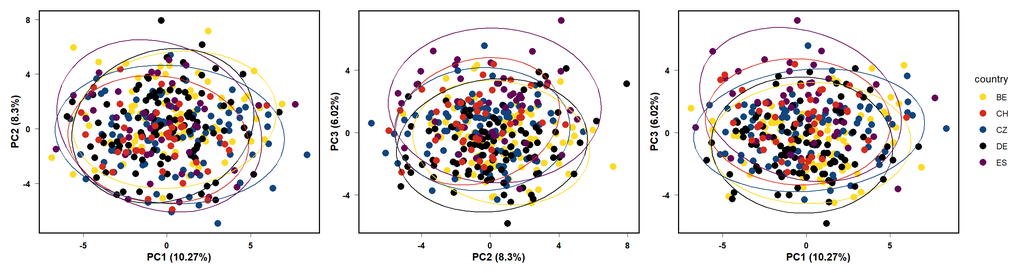

```r
spca_plot_df <- merge(
  spca_integrated_df %>% rownames_to_column("study_id"),
  metadata_df,by="study_id")

p1 <- pca_plot(spca_integrated_df,
              metadata_df,
              color_col = "country",
              perform_pca = FALSE,axis = c("PC1","PC2"))

p1 <- ggtheme(p1)

p2 <- pca_plot(spca_integrated_df,
              metadata_df,
              color_col = "country",
              perform_pca = FALSE,axis = c("PC2","PC3"))

p2 <- ggtheme(p2)

p3 <- pca_plot(spca_integrated_df,
              metadata_df,
              color_col = "country",
              perform_pca = FALSE,axis = c("PC1","PC3"))

p3 <- ggtheme(p3)

p1 + p2 + p3 +
plot_layout(guides = "collect")
```

### 3.1.2 Boxplots

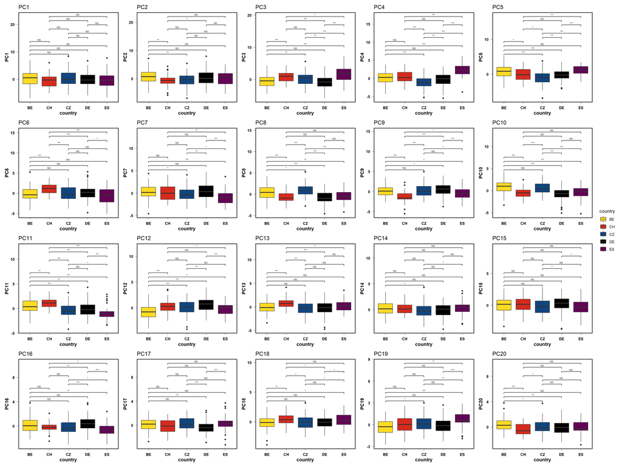

```r
spca_for_uni <- merge(spca_integrated_df %>% rownames_to_column("study_id"),
                      metadata_scaled_df,by="study_id",all = TRUE)

plot_list <- list()
for (col in colnames(spca_integrated_df)){
  p <- ggplot(spca_for_uni,
              aes_string(x = "country",y = col,fill="country")) +
    geom_boxplot() +
    ggtitle(col) +
    theme_minimal() +
    scale_fill_manual(values=c(
      BE = "#FDDA24",   # gold
      CZ = "#11457E",   # blue
      DE = "#000000",   # black
      ES = "#630356",   # purple
      CH = "#D52B1E"    # red
    )) +
    geom_signif(comparisons =
                  combn(as.character(unique(spca_for_uni$country)),
                        m=2, simplify = FALSE),
                map_signif_level = TRUE, step_increase = 0.1,textsize = 2)

  p <- ggtheme(p)
  plot_list[[length(plot_list) + 1]] <- p
}


a <- wrap_plots(plot_list,guides = "collect")

a
```

### 3.1.3 Heatmap

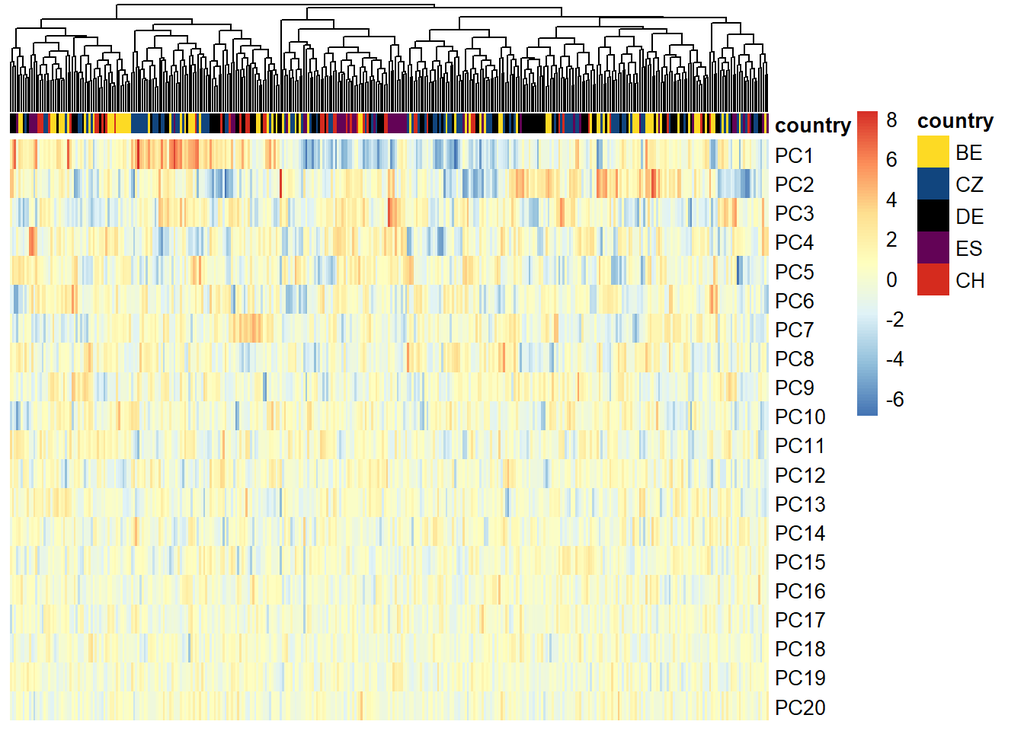

```r
library(pheatmap)

country_colors <- c(
  BE = "#FDDA24",  # gold
  CZ = "#11457E",  # blue
  DE = "#000000",  # black
  ES = "#630356",  # purple
  CH = "#D52B1E"   # red
)

p_df <- spca_integrated_df %>% t()

ann_df <- metadata_df %>% dplyr::select(study_id,country) %>%
  column_to_rownames("study_id")

ann_colors <- list(
  "country"=country_colors
)
names(ann_colors[["country"]]) <- names(country_colors)

p <- pheatmap(p_df,cluster_rows = FALSE,show_colnames = FALSE,
              annotation_col = ann_df,
              annotation_colors = ann_colors,silent = TRUE)

p
```

## 3.2 PERMANOVA

The test shows how much of the variation in the metabolome is explained by sex, age, BMI, VS_total, vegan duration, and country.

Variables were added sequentially (Type I sums of squares), so each p-value and R² reflects a partial effect after adjusting for the variables above it. The model first accounts for variation due to sex, age, vegan diet duration, and BMI, and then for the main effect of country.

Country explains **9.08%** of the variation after adjusting for sex, age, BMI, VS_total, and diet duration. This result is statistically significant (p<0.001).

```r
metadata_to_test <- metadata_scaled_df %>% drop_na(VS_total,vegan_duration)

# Create Euclidean distance matrix
dist_mat <- vegdist(spca_integrated_df,
                    method = "euclidean")

# Test whether countries differ in metabolomics
adonis_result <- adonis2(
  dist_mat ~ sex + bmi + age + VS_total + vegan_duration + country,
  data = metadata_scaled_df ,
  permutations = 999,
  by="terms")

print(adonis_result)
```

```
Permutation test for adonis under reduced model
Terms added sequentially (first to last)
Permutation: free
Number of permutations: 999

adonis2(formula = dist_mat ~ sex + bmi + age + VS_total + vegan_duration + country, data = metadata_scaled_df, permutations = 999, by = "terms")
                Df SumOfSqs      R2       F Pr(>F)
sex              1   1103.5 0.05624 24.4278  0.001 ***
bmi              1    168.6 0.00859  3.7323  0.001 ***
age              1    250.8 0.01278  5.5524  0.001 ***
VS_total         1    590.2 0.03008 13.0651  0.001 ***
vegan_duration   1     51.3 0.00261  1.1351  0.323
country          4   1781.4 0.09079  9.8588  0.001 ***
Residual       347  15675.1 0.79890
Total          356  19620.9 1.00000
---
Signif. codes:  0 '***' 0.001 '**' 0.01 '*' 0.05 '.' 0.1 ' ' 1
```

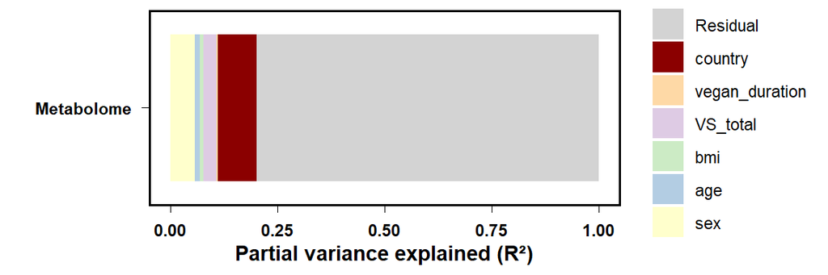

```r
adonis_result <- adonis_result[-8,] %>% rownames_to_column("Var")
adonis_result$Var <- factor(adonis_result$Var,levels = rev(c("sex","age","bmi","VS_total", "vegan_duration","country", "Residual")))
p <- ggplot(adonis_result, aes(fill=Var, x=R2, y="Metabolome")) +
    geom_bar(position="stack", stat="identity") +
  ylab("") + xlab("Partial variance explained (R²)") +
  scale_fill_manual(values=rev(c("#ffffcc","#b3cde3","#ccebc5",
                                 "#decbe4","#fed9a6","darkred",
                                 "lightgrey")),name = "Covariate")

p <- ggtheme(p)

p
```

```r
p_pca[[2]] <- p
p_pca[[3]] <- adonis_result
```

**Pairwise PERMANOVA**

```r
pp_main <- pairwise.adonis(x = t(spca_integrated_df),
                metadata = metadata_scaled_df %>%
                  dplyr::mutate(SampleID=study_id),
                formula = "dist_mat ~ sex + bmi + age + VS_total + vegan_duration + country",main_variable = "country",
                sim.method = "euclidean"
                  )
```

```r
pp_main
```

```
$`BE vs CZ`
                Df   SumOfSqs          R2         F Pr(>F)   sig
sex              1  616.25125 0.067252204 13.443016  0.001   ***
bmi              1   89.45703 0.009762548  1.951432  0.024     *
age              1  150.44211 0.016417919  3.281771  0.001   ***
VS_total         1  301.42754 0.032895132  6.575395  0.001   ***
vegan_duration   1   52.25969 0.005703160  1.140002  0.286 0.286
country          1  343.72057 0.037510619  7.497982  0.001   ***
Residual       166 7609.72897 0.830458419        NA     NA  <NA>
Total          172 9163.28717 1.000000000        NA     NA  <NA>

$`BE vs DE`
                Df   SumOfSqs          R2         F Pr(>F)   sig
sex              1  487.06304 0.052332073 10.702441  0.001   ***
bmi              1   90.78140 0.009753930  1.994778  0.018     *
age              1  144.74036 0.015551505  3.180441  0.001   ***
VS_total         1  357.78396 0.038441792  7.861738  0.001   ***
vegan_duration   1   60.49424 0.006499752  1.329265  0.175 0.175
country          1  293.15002 0.031497254  6.441509  0.001   ***
Residual       173 7873.14820 0.845923694        NA     NA  <NA>
Total          179 9307.16122 1.000000000        NA     NA  <NA>

$`BE vs ES`
                Df   SumOfSqs         R2        F Pr(>F)  sig
sex              1  410.03164 0.05924305 8.790261  0.001  ***
bmi              1   99.65204 0.01439813 2.136341  0.013    *
age              1  156.80212 0.02265541 3.361525  0.001  ***
VS_total         1  232.68027 0.03361860 4.988201  0.001  ***
vegan_duration   1   94.10789 0.01359709 2.017486  0.015    *
country          1  423.66048 0.06121220 9.082437  0.001  ***
Residual       118 5504.24279 0.79527552       NA     NA <NA>
Total          124 6921.17722 1.00000000       NA     NA <NA>

$`BE vs CH`
                Df   SumOfSqs          R2         F Pr(>F)   sig
sex              1  401.57130 0.063475865 9.5572993  0.001   ***
bmi              1  114.69118 0.018129089 2.7296222  0.004    **
age              1  160.40765 0.025355433 3.8176630  0.001   ***
VS_total         1  321.02198 0.050743537 7.6402452  0.001   ***
vegan_duration   1   40.87487 0.006461038 0.9728119  0.456 0.456
```

[output cut: 54 more lines]

```
vegan_duration   1   24.32769 0.00349527 0.5635215  0.913 0.913
country          1  334.10294 0.04800208 7.7390886  0.001   ***
Residual       134 5784.89223 0.83114161        NA     NA  <NA>
Total          140 6960.17643 1.00000000        NA     NA  <NA>

$`ES vs CH`
               Df   SumOfSqs          R2         F Pr(>F)   sig
sex             1  319.75916 0.071071033 7.3524386  0.001   ***
bmi             1   65.86913 0.014640354 1.5145735  0.099 0.099
age             1  146.19008 0.032492830 3.3614474  0.001   ***
VS_total        1  140.79422 0.031293524 3.2373768  0.002    **
vegan_duration  1   30.93537 0.006875827 0.7113179  0.768 0.768
country         1  359.87372 0.079987066 8.2748199  0.001   ***
Residual       79 3435.72724 0.763639366        NA     NA  <NA>
Total          85 4499.14894 1.000000000        NA     NA  <NA>
```

## 3.3 RF model

Model performance was tested for significance using a bootstrap-based z-test. The AUC was estimated over 500 bootstrap resamples, and the bootstrap standard error was used to compute a Wald-type statistic, z = (AUC − 0.5)/SE, with p-values obtained from the standard normal distribution.

### 3.3.1 Original model

```r
model_name <- "country_model_vegan"

prepared_df <- model_preparation(spca_integrated_df,
                                 metadata_df,
                                 predicting_col = "country")

rf_model <- make_rf_model(data=prepared_df,
                          outcome="Group",
                          N = 500,
                          file = model_name,
                          reuse=TRUE)

rf_model$model_summary
```

```
  mtry splitrule min.node.size       auc  accuracy   auc_CIL   auc_CIU
1    5      gini             2 0.8947565 0.6115382 0.8535866 0.9243465
  accuracy_CIL accuracy_CIU
1    0.5252318    0.6873194
```

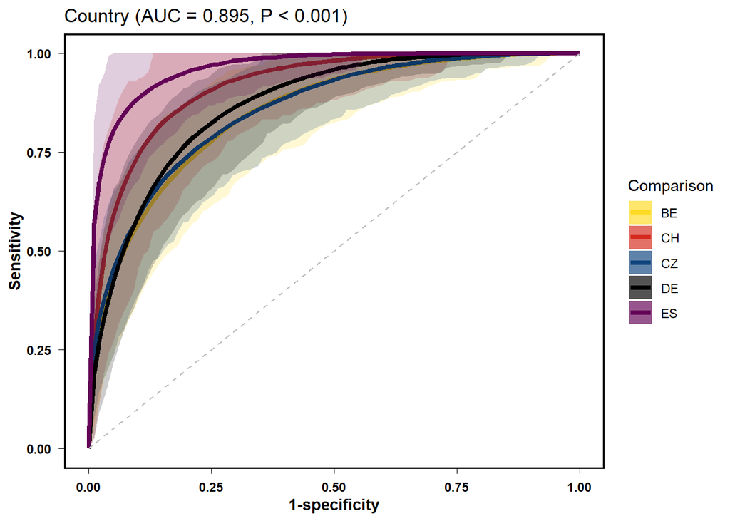

```r
roc_c <- roc_curve(model_object = rf_model,CI = TRUE)

roc_c <- ggtheme(roc_c)

roc_c
```

**Accuracy**

```r
mean((rf_model$predictions %>%
  dplyr::group_by(iteration) %>%
  dplyr::summarize(accuracy = mean(predicted == outcome, na.rm = TRUE)))$accuracy)
```

```
[1] 0.6115382
```

```r
# saving the results
save_rf_details("../results/vegan/RF_models_performance.xlsx",model_name,rf_model)
```

```
[1] "Results saved to ../results/vegan/RF_models_performance.xlsx"
```

### 3.3.2 Regressed out model

```r
# Covariates to adjust for
covars <- c("sex","bmi", "age", "VS_total", "vegan_duration")
integrated_df <- spca_integrated_df
all(rownames(integrated_df) == metadata_df$study_id)
```

```
[1] TRUE
```

```r
adjusted_data <- adjust_for_covars(integrated_df, covars, metadata_scaled_df)

model_name <- "adjusted_country_model_vegan"

prepared_df <- model_preparation(adjusted_data,
                                 metadata_df,
                                 predicting_col = "country")

rf_model <- make_rf_model(data=prepared_df,
                          outcome="Group",
                          N = 500,
                          file = model_name,
                          reuse=TRUE)
rf_model$model_summary
```

```
  mtry splitrule min.node.size       auc accuracy   auc_CIL   auc_CIU
1    5      gini             2 0.8713552 0.577244 0.8267528 0.9049441
  accuracy_CIL accuracy_CIU
1       0.4923    0.6498266
```

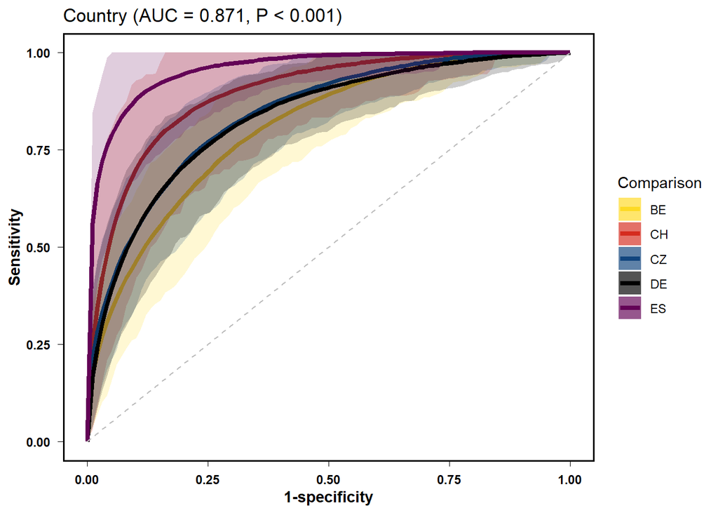

```r
roc_c <- roc_curve(model_object = rf_model,CI = TRUE)

roc_c <- ggtheme(roc_c)

roc_c
```

```r
f <- roc_c
save(f,file="../results/vegan/figures/F3a_ROCcountry.RData")
```

**Confusion matrix**

```r
conf_matrix <- rf_model$predictions %>%
  group_by(iteration, outcome, predicted) %>%
  summarise(n = n(), .groups = "drop") %>%
  group_by(outcome, predicted) %>%
  summarise(mean_count = mean(n), .groups = "drop") %>%
  pivot_wider(names_from = predicted, values_from = mean_count, values_fill = 0) %>%
  as.data.frame()

conf_matrix
```

```
  outcome         0        1         2         3        4
1       0 16.068000 1.247573  5.983903  7.376000 1.451613
2       1  2.785714 4.738431  3.175365  4.967413 1.439394
3       2  6.096774 1.369231 21.474000  5.128773 1.094937
4       3  4.604938 1.793333  6.116935 24.556000 1.107843
5       4  2.738717 1.322581  1.823370  2.534831 9.120000
```

```r
conf_matrix[,-1] <- conf_matrix[,-1]/rowSums(conf_matrix[,-1])

conf_matrix
```

```
  outcome         0          1         2         3          4
1       0 0.5001387 0.03883243 0.1862573 0.2295882 0.04518346
2       1 0.1628471 0.27699887 0.1856253 0.2903847 0.08414400
3       2 0.1733825 0.03893874 0.6106863 0.1458541 0.03113826
4       3 0.1206143 0.04697166 0.1602171 0.6431800 0.02901704
5       4 0.1561457 0.07540584 0.1039579 0.1445213 0.51996924
```

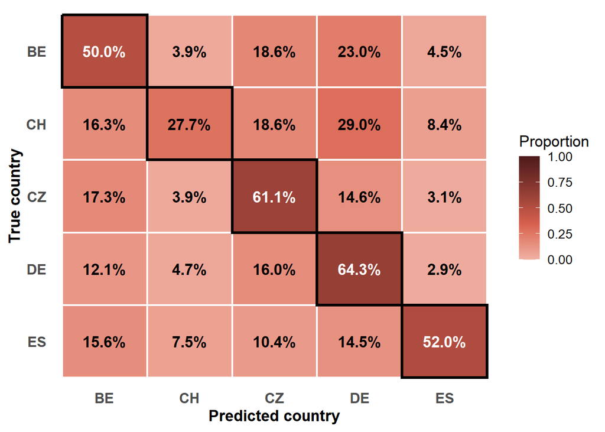

```r
conf_matrix <- conf_matrix[,-1]
countries <- as.character(rf_model$mapping)
rownames(conf_matrix) <- countries
colnames(conf_matrix) <- countries

p <- confusion_matrix_plot(conf_matrix,countries)
p
```

```r
f <- p
save(f,file="../results/vegan/figures/F3b_CMcountry.RData")
```

```r
# saving the results
save_rf_details("../results/vegan/RF_models_performance.xlsx",model_name,rf_model)
```

```
[1] "Results saved to ../results/vegan/RF_models_performance.xlsx"
```

## 3.4 RF importance

### 3.4.1 Original model

**PC4** and **PC10** are the most important variables for the RF model, although the importance does not drop off sharply across the remaining PCs.

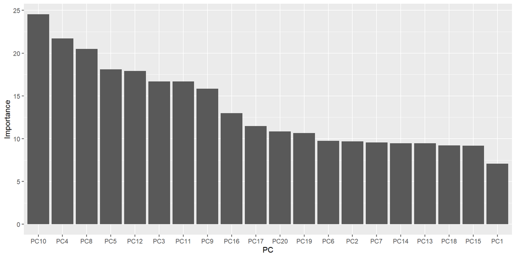

```r
load("../intermediate_files/models/country_model_vegan/rf_model.RData")

var_imp <- as.data.frame(importance(rf_model$trained_model)) %>%
  rownames_to_column("PC") %>%
  `colnames<-`(c("PC","Importance"))

var_imp <- var_imp %>% dplyr::mutate(PC=factor(PC,levels = PC[order(var_imp$Importance,decreasing = TRUE)]))

ggplot(var_imp) +
  geom_col(aes(x=PC,y=Importance))
```

### 3.4.2 Adjusted model

As above, **PC4** is the most important variable, while **PC10** drops in importance compared with the original model.

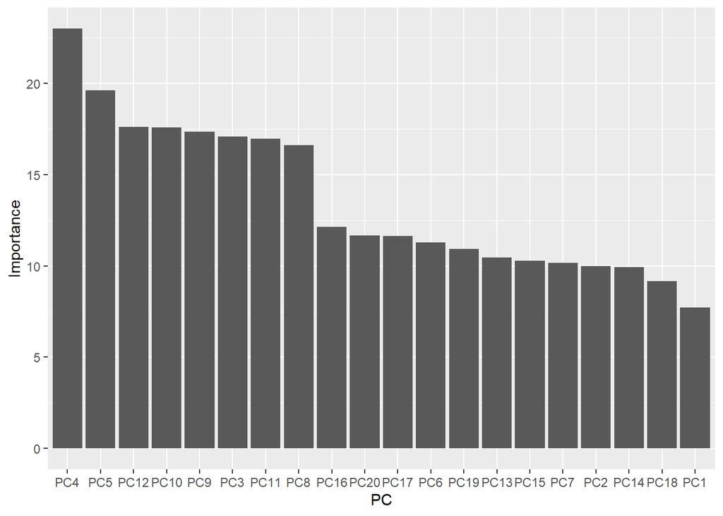

```r
load("../intermediate_files/models/adjusted_country_model_vegan/rf_model.RData")

var_imp <- as.data.frame(importance(rf_model$trained_model)) %>%
  rownames_to_column("PC") %>%
  `colnames<-`(c("PC","Importance"))

var_imp <- var_imp %>% dplyr::mutate(PC=factor(PC,levels = PC[order(var_imp$Importance,decreasing = TRUE)]))

ggplot(var_imp) +
  geom_col(aes(x=PC,y=Importance))
```

### 3.4.3 Visualization

To explore these two important PCs further, their visualizations are shown below.

*PCA*

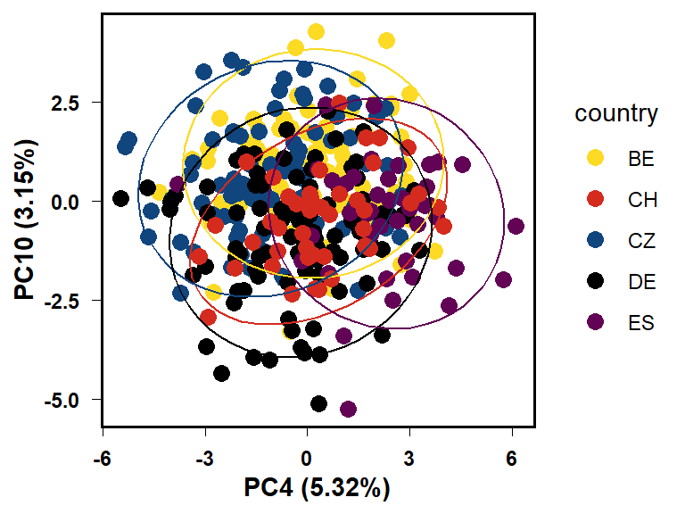

```r
spca_plot_df <- merge(
  spca_integrated_df %>% rownames_to_column("study_id"),
  metadata_scaled_df,by="study_id")

p <- pca_plot(spca_integrated_df,
              metadata_df,
              color_col = "country",
              perform_pca = FALSE,
              axis = c("PC4","PC10"))

p <- ggtheme(p)

p
```

```r
p_pca[[4]] <- p
```

*Boxplots*

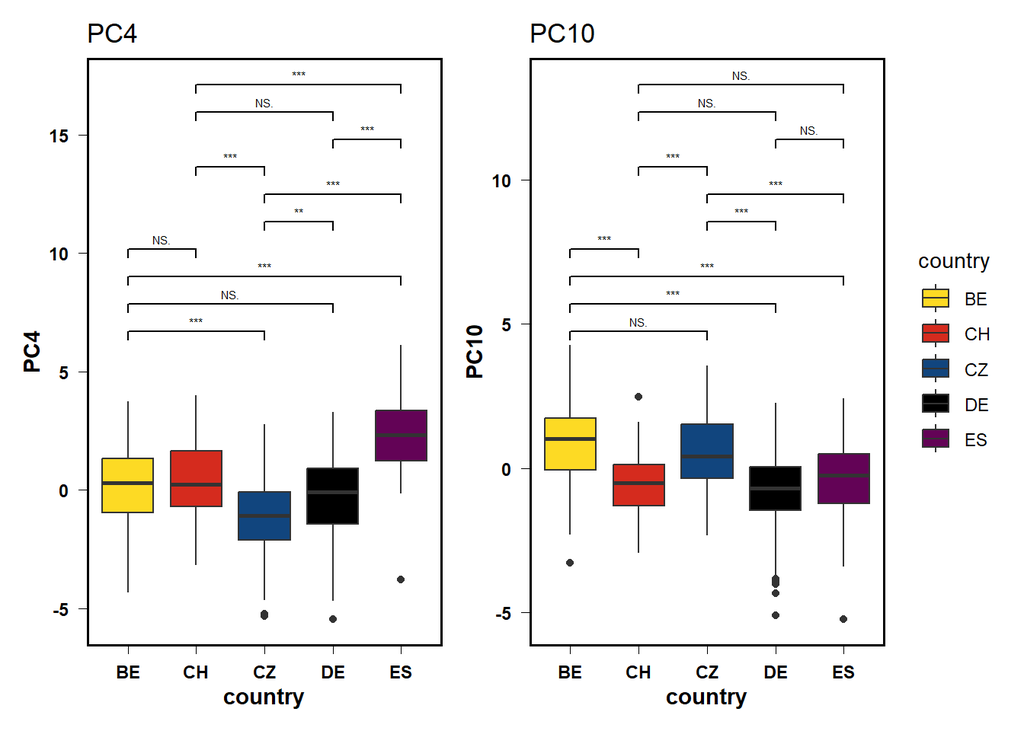

```r
plot_list <- list()
for (col in c("PC4","PC10")){
 p <- ggplot(spca_for_uni, aes_string(x = "country",y = col,fill="country")) +
    geom_boxplot() +
    ggtitle(col) +
    theme_minimal() +
    scale_fill_manual(values=c(
      BE = "#FDDA24",   # gold
      CZ = "#11457E",   # blue
      DE = "#000000",   # black
      ES = "#630356",   # purple
      CH = "#D52B1E"    # red
    )) +
    geom_signif(comparisons =
                  combn(as.character(unique(spca_for_uni$country)),
                        m=2, simplify = FALSE),
                map_signif_level = TRUE, step_increase = 0.1,textsize = 2)

  p <- ggtheme(p)
  plot_list[[length(plot_list) + 1]] <- p
}


a <- wrap_plots(plot_list,guides = "collect")

a
```

## 3.5 SPCA loadings

Here, the loadings of the two important PCs (**PC4** and **PC10**) are examined and saved.

```r
load("../results/preprocessing/spca_result_vegans_INT_v3.RData")

df <- data.frame (
  Metabolite=names(spca_result$loadings$X[,4]),
  Loading=spca_result$loadings$X[,4])

df
##                                          Metabolite      Loading
## Formate                                     Formate  0.162256722
## Inosine                                     Inosine  0.194791520
## Phenylalanine                         Phenylalanine  0.019794678
## Histidine                                 Histidine  0.073179564
## Tyrosine                                   Tyrosine -0.012383169
## Ascorbate                                 Ascorbate -0.007886155
## Threonine                                 Threonine  0.095512094
## Lactate                                     Lactate -0.199193647
## Glucose                                     Glucose  0.186323579
## Glycine                                     Glycine  0.032563745
## Lysine                                       Lysine -0.034924423
## Asparagine                               Asparagine  0.011425738
## Methylguanidine                     Methylguanidine  0.078396512
## Dimethylamine                         Dimethylamine  0.052474161
## X2.Oxoisocaproate                 X2.Oxoisocaproate -0.017472224
## Citrate                                     Citrate  0.084251493
## Pyruvate                                   Pyruvate -0.136657274
## X3.Hydroxybutyrate               X3.Hydroxybutyrate -0.001942941
## Acetone                                     Acetone -0.035169322
## Acetate                                     Acetate -0.004396180
## Alanine                                     Alanine -0.048954017
## X3.Methyl.2.oxovalerate     X3.Methyl.2.oxovalerate  0.013751019
## Valine                                       Valine -0.111688313
## Isoleucine                               Isoleucine -0.100210675
## X2.Hydroxybutyrate               X2.Hydroxybutyrate -0.032153567
## PC.20.3.OH.P.18.1.               PC.20.3.OH.P.18.1.  0.099185707
## PC.P.38.4.                               PC.P.38.4.  0.117533732
## Caffeine                                   Caffeine -0.119809430
## CE.18.2..M.NH4..                   CE.18.2..M.NH4.. -0.114682384
## PC.36.4.                                   PC.36.4.  0.096252388
## PA.44.5.                                   PA.44.5. -0.106400740
## PC.32.1.                                   PC.32.1. -0.149039805
## PC.34.1.                                   PC.34.1. -0.004313869
## PC.36.2.                                   PC.36.2.  0.206629586
## PC.38.4.                                   PC.38.4.  0.041908471
## PC.40.6.                                   PC.40.6. -0.104188713
## PC.P.38.4..PC.O.38.5.         PC.P.38.4..PC.O.38.5.  0.121469251
## SM.d38.2.                                 SM.d38.2.  0.032205015
## SM.d42.2.                                 SM.d42.2. -0.065342408
## SM.d33.1.                                 SM.d33.1.  0.001114315
## SM.d34.1.                                 SM.d34.1.  0.049218223
## LysoPC.22.6.                           LysoPC.22.6. -0.096108205
## SM.d32.1.                                 SM.d32.1. -0.169238478
## LysoPC.P.16.0.                       LysoPC.P.16.0.  0.013853406
## Indoleacrylic.acid               Indoleacrylic.acid  0.095245442
## LysoPC.17.0.                           LysoPC.17.0.  0.082267930
## LysoPC.18.2.                           LysoPC.18.2.  0.150493152
## Dodecenoylcarnitine             Dodecenoylcarnitine -0.002874909
## LysoPC.14.0.                           LysoPC.14.0. -0.184159843
## Uric.acid                                 Uric.acid -0.138918183
## Acylcarnitine..C8.               Acylcarnitine..C8. -0.005289719
## Octenoylcarnitine                 Octenoylcarnitine -0.255948328
## Hexanoylcarnitine                 Hexanoylcarnitine -0.121259396
## Hydroxydecanoylcarnitine   Hydroxydecanoylcarnitine  0.008794758
## Acylcarnitine..C5.               Acylcarnitine..C5. -0.186317953
## Hydroxyoctanoylcarnitine   Hydroxyoctanoylcarnitine -0.026538875
## Butyrylcarnitine                   Butyrylcarnitine -0.083823777
## Phenylalanylphenylalanine Phenylalanylphenylalanine -0.188668364
## Propionylcarnitine               Propionylcarnitine -0.103563829
## Betaine                                     Betaine  0.043125435
## Tryptophan                               Tryptophan  0.075396698
## Diaminonaphthalene               Diaminonaphthalene  0.135313214
## Creatinine                               Creatinine  0.100436286
## Glutarylcarnitine                 Glutarylcarnitine -0.019905617
## Hydroxybutyrylcarnitine     Hydroxybutyrylcarnitine -0.083320348
## Glutarylcarnitine.1             Glutarylcarnitine.1  0.084623004
## Ergothionenine                       Ergothionenine  0.149658595
## Carnitine                                 Carnitine -0.151284555
## Acetylornithin                       Acetylornithin  0.037696885
## Glutamine                                 Glutamine  0.270453971
## Phenylbutyrylglutamine       Phenylbutyrylglutamine  0.227417345
## Glycerophosphocholine         Glycerophosphocholine -0.119618138
## Citrulline..M.Na.                 Citrulline..M.Na.  0.258150140
## Glutamylglutamine                 Glutamylglutamine -0.075881260
## Trimethyllysine                     Trimethyllysine -0.045964386

write.table(df,sep="\t","../results/vegan/Q1_country/loadings_PC4.tsv")
```

This plot shows the loadings of individual metabolites on **PC4**, ordered by absolute value.

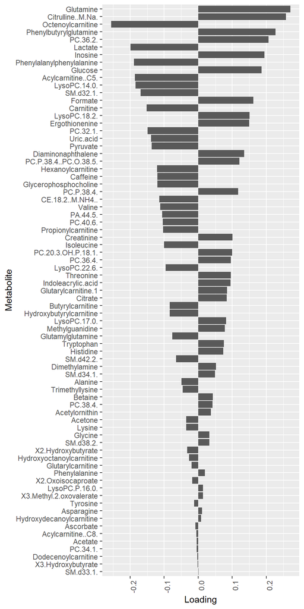

```r
ggplot(df %>% dplyr::mutate(
           Metabolite=factor(
             Metabolite,
             levels = Metabolite[order(abs(Loading),decreasing = FALSE)])
           )) +
  geom_col(aes(x=Metabolite,y=Loading)) +
  theme(axis.text.x = element_text(angle=90,hjust = 1)) +
  coord_flip()
```

```r
spca_loadings <- df$Metabolite[abs(df$Loading)>=0.1]
```

```r
df <- data.frame (
  Metabolite=names(spca_result$loadings$X[,10]),
  Loading=spca_result$loadings$X[,10])

write.table(df,sep="\t","../results/vegan/Q1_country/loadings_PC10.tsv")
```

This plot shows the loadings of individual metabolites on **PC10**, ordered by absolute value.

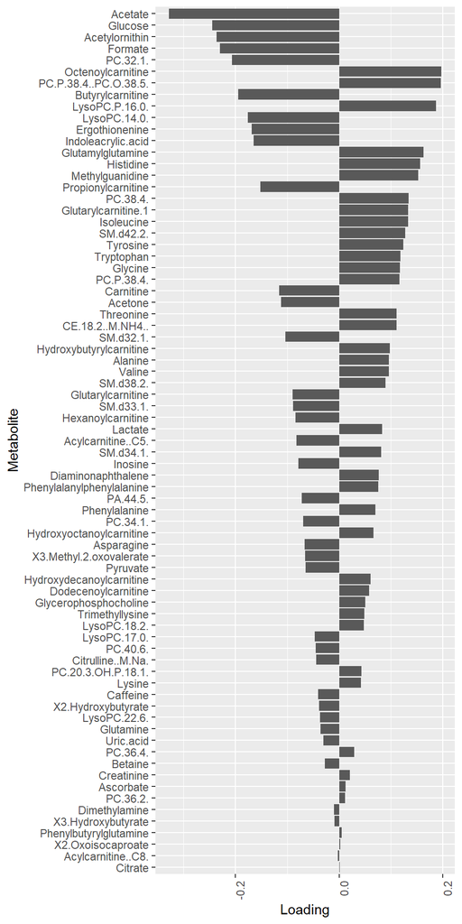

```r
ggplot(df %>%
         dplyr::mutate(
           Metabolite=factor(Metabolite,
                             levels = Metabolite[order(abs(Loading),decreasing = FALSE)])
           )) +
  geom_col(aes(x=Metabolite,y=Loading)) +
  theme(axis.text.x = element_text(angle=90,hjust = 1)) +
  coord_flip()
```

```r
spca_loadings <- c(spca_loadings,df$Metabolite[abs(df$Loading)>=0.1])
```

# 4 Concatenated dataset

```r
concat_integrated_df <- cbind(lcms_df,nmr_df)
```

## 4.1 Visualization

### 4.1.1 Boxplots

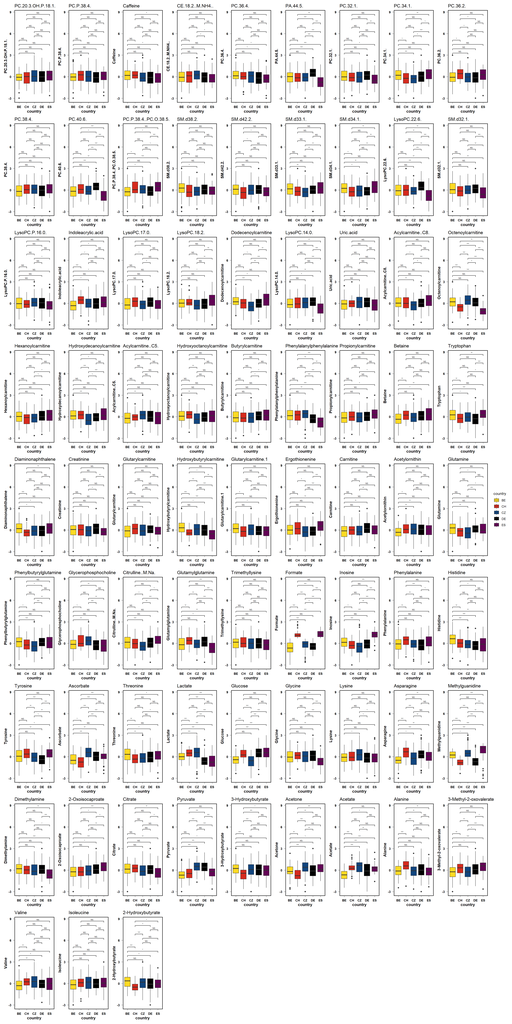

```r
concat_for_uni <- merge(concat_integrated_df %>% rownames_to_column("study_id"),
                      metadata_scaled_df,by="study_id",all = TRUE)

plot_list <- list()
for (col in colnames(concat_integrated_df)){
  p <- ggplot(concat_for_uni,
              aes(x = country,y = !!sym(col),fill=country)) +
    geom_boxplot() +
    ggtitle(col) +
    theme_minimal() +
    scale_fill_manual(values=c(
      BE = "#FDDA24",   # gold
      CZ = "#11457E",   # blue
      DE = "#000000",   # black
      ES = "#630356",   # purple
      CH = "#D52B1E"    # red
    )) +
    geom_signif(comparisons =
                  combn(as.character(unique(concat_for_uni$country)),
                        m=2, simplify = FALSE),
                map_signif_level = TRUE, step_increase = 0.1,textsize = 2)

  p <- ggtheme(p)
  plot_list[[length(plot_list) + 1]] <- p
}


a <- wrap_plots(plot_list,guides = "collect")

a
```

### 4.1.2 Heatmap

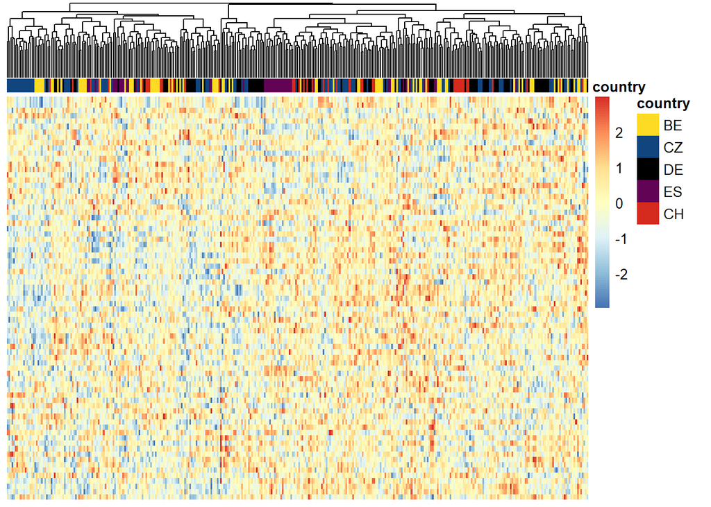

```r
library(pheatmap)
p_df <- concat_integrated_df %>% t()

ann_df <- metadata_df %>% dplyr::select(study_id,country) %>%
  column_to_rownames("study_id")

ann_colors <- list(
  "country"=country_colors
)
names(ann_colors[["country"]]) <- names(country_colors)

p <- pheatmap(p_df,cluster_rows = FALSE,show_colnames = FALSE,
              show_rownames = FALSE,
              annotation_col = ann_df,
              annotation_colors = ann_colors,silent = TRUE)

p
```

## 4.2 Univariate analysis

A linear model (lm) is used to test for differences between countries while adjusting for covariates:

Metabolite ~ sex + bmi + age + VS_total + vegan_duration + Country

### 4.2.1 LM

**LM**

```r
results_list <- lapply(colnames(concat_integrated_df),
                       function(x) fit_netglm(x,concat_for_uni,
                                           tested_variable = "country"))
results_df <- do.call(rbind, results_list)

country_effects <- results_df %>%
  dplyr::mutate(p_adj = p.adjust(`p.value`, method = "BH"))

concat_significant <-  country_effects %>%
  filter(p_adj < 0.05)

# save and show
write.table(concat_significant,"../results/vegan/Q1_country/lm_emmeans.tsv",
            row.names = FALSE,
            quote=FALSE,
            sep="\t")

knitr::kable(concat_significant)
```

| metabolite | country | emmean | p.value | lower.CL | upper.CL | p_adj |
| --- | --- | --- | --- | --- | --- | --- |
| CE.18.2..M.NH4.. | CZ | 0.2655465 | 0.0132931 | 0.0556760 | 0.4754170 | 0.0449093 |
| PC.36.4. | BE | 0.2942523 | 0.0110501 | 0.0677238 | 0.5207809 | 0.0390923 |
| PA.44.5. | DE | 0.3362250 | 0.0003623 | 0.1526159 | 0.5198340 | 0.0023846 |
| PA.44.5. | ES | -0.7341994 | 0.0000001 | -1.0022783 | -0.4661206 | 0.0000023 |
| PC.32.1. | DE | 0.2956334 | 0.0036172 | 0.0971644 | 0.4941024 | 0.0165420 |
| PC.32.1. | ES | -0.3769838 | 0.0109288 | -0.6667590 | -0.0872086 | 0.0390316 |
| PC.34.1. | CZ | -0.3709081 | 0.0001666 | -0.5625538 | -0.1792625 | 0.0012492 |
| PC.40.6. | DE | 0.3508907 | 0.0001820 | 0.1684864 | 0.5332951 | 0.0013386 |
| PC.40.6. | ES | -0.7488065 | 0.0000001 | -1.0151265 | -0.4824866 | 0.0000014 |
| PC.P.38.4..PC.O.38.5. | ES | 0.3976573 | 0.0069692 | 0.1095301 | 0.6857845 | 0.0275099 |
| SM.d34.1. | ES | 0.4941535 | 0.0008095 | 0.2065410 | 0.7817660 | 0.0045995 |
| LysoPC.22.6. | DE | 0.3388017 | 0.0003801 | 0.1531195 | 0.5244840 | 0.0024575 |
| LysoPC.22.6. | ES | -0.6928854 | 0.0000008 | -0.9639913 | -0.4217795 | 0.0000120 |
| SM.d32.1. | DE | 0.2596279 | 0.0055265 | 0.0767409 | 0.4425150 | 0.0232857 |
| SM.d32.1. | ES | -0.5444629 | 0.0000743 | -0.8114875 | -0.2774382 | 0.0006793 |
| Indoleacrylic.acid | CH | 0.3662613 | 0.0094847 | 0.0901078 | 0.6424148 | 0.0341997 |
| LysoPC.18.2. | ES | 0.4145637 | 0.0045153 | 0.1293062 | 0.6998212 | 0.0194625 |
| Dodecenoylcarnitine | CZ | -0.4369283 | 0.0000249 | -0.6380103 | -0.2358463 | 0.0002591 |
| Dodecenoylcarnitine | ES | 0.4896633 | 0.0009657 | 0.2003478 | 0.7789787 | 0.0053256 |
| LysoPC.14.0. | DE | 0.2545680 | 0.0119982 | 0.0563137 | 0.4528223 | 0.0412783 |
| LysoPC.14.0. | ES | -0.6272611 | 0.0000261 | -0.9167229 | -0.3377994 | 0.0002648 |
| Acylcarnitine..C8. | CZ | -0.3089276 | 0.0032805 | -0.5141506 | -0.1037046 | 0.0155721 |
| Acylcarnitine..C8. | ES | 0.3811289 | 0.0115626 | 0.0858553 | 0.6764025 | 0.0401479 |
| Octenoylcarnitine | CH | -0.4999583 | 0.0000547 | -0.7406497 | -0.2592670 | 0.0005126 |
| Octenoylcarnitine | CZ | 0.3664593 | 0.0000212 | 0.1992750 | 0.5336435 | 0.0002276 |
| Octenoylcarnitine | DE | 0.2535613 | 0.0026540 | 0.0888114 | 0.4183113 | 0.0129252 |
| Octenoylcarnitine | ES | -0.9719778 | 0.0000000 | -1.2125214 | -0.7314342 | 0.0000000 |
| Hydroxydecanoylcarnitine | BE | 0.3292279 | 0.0027481 | 0.1145460 | 0.5439098 | 0.0132119 |
| Hydroxydecanoylcarnitine | CZ | -0.4125476 | 0.0000486 | -0.6097794 | -0.2153157 | 0.0004675 |
| Hydroxydecanoylcarnitine | ES | 0.3863511 | 0.0077639 | 0.1025752 | 0.6701270 | 0.0297089 |

[output cut: 82 more lines]

```r
results_all <- country_effects

# save
write.table(results_all,"../results/vegan/Q1_country/lm_emmeans_all.tsv",
            row.names = FALSE,
            quote=FALSE,
            sep="\t")
```

**Dispersion**

```r
dispersion <- country_effects %>%
  group_by(metabolite) %>%
  summarise(
    range      = max(emmean) - min(emmean),      # simplest: spread between highest and lowest country
    sd         = sd(emmean),                      # standard deviation of the 5 country means
    cv         = sd(emmean) / abs(mean(emmean)),  # coefficient of variation (relative dispersion)
    min_mean   = min(emmean),
    max_mean   = max(emmean),
    min_country = country[which.min(emmean)],
    max_country = country[which.max(emmean)]
  ) %>%
  arrange(desc(range))

dispersion
```

```
# A tibble: 75 × 8
   metabolite       range    sd     cv min_mean max_mean min_country max_country
   <chr>            <dbl> <dbl>  <dbl>    <dbl>    <dbl> <fct>       <fct>
 1 Formate           1.93 0.940   3.71   -0.644    1.29  BE          ES
 2 Inosine           1.63 0.623   8.22   -0.512    1.11  CZ          ES
 3 Methylguanidine   1.57 0.758 476.     -0.867    0.706 CH          ES
 4 Ascorbate         1.37 0.500   4.35   -0.778    0.596 CH          CZ
 5 Octenoylcarniti…  1.34 0.576   4.18   -0.972    0.366 ES          CZ
 6 Glucose           1.19 0.551   9.23   -0.616    0.574 CZ          ES
 7 Pyruvate          1.17 0.535   5.12   -0.678    0.496 BE          DE
 8 Lactate           1.16 0.549  47.0    -0.590    0.568 ES          CH
 9 Phenylalanylphe…  1.10 0.457   8.12   -0.767    0.333 ES          CZ
10 PC.40.6.          1.10 0.404   4.29   -0.749    0.351 ES          DE
# ℹ 65 more rows
```

```r
write.table(dispersion,"../results/vegan/Q1_country/dispersion.tsv",sep="\t",row.names = FALSE,quote=FALSE)
```

```r
results_list_pairwise <- lapply(colnames(concat_integrated_df),
                       function(x) fit_netglm_pairwise(x,concat_for_uni,
                                           tested_variable = "country"))
results_df_pairwise <- do.call(rbind, results_list_pairwise)

country_effects_pairwise <- results_df_pairwise %>%
  dplyr::mutate(p_adj = p.adjust(`p.value`, method = "BH"))

concat_significant_pairwise <-  country_effects_pairwise %>%
  filter(p_adj < 0.05)

knitr::kable(concat_significant_pairwise)
```

| contrast | estimate | SE | df | t.ratio | p.value | Metabolite | p_adj |
| --- | --- | --- | --- | --- | --- | --- | --- |
| BE - ES | 0.7457452 | 0.1700905 | 347 | 4.384403 | 0.0001497 | PA.44.5. | 0.0014583 |
| CZ - ES | 0.6988412 | 0.1649471 | 347 | 4.236759 | 0.0002801 | PA.44.5. | 0.0025622 |
| DE - ES | 1.0704244 | 0.1658947 | 347 | 6.452434 | 0.0000000 | PA.44.5. | 0.0000001 |
| DE - ES | 0.6726172 | 0.1793210 | 347 | 3.750912 | 0.0019183 | PC.32.1. | 0.0124025 |
| CZ - DE | -0.5584045 | 0.1394268 | 347 | -4.005000 | 0.0007204 | PC.34.1. | 0.0059373 |
| CZ - ES | -0.6943423 | 0.1696601 | 347 | -4.092550 | 0.0005071 | PC.34.1. | 0.0043712 |
| BE - ES | 0.6404538 | 0.1689745 | 347 | 3.790239 | 0.0016549 | PC.40.6. | 0.0110821 |
| CH - ES | 0.8026614 | 0.1913580 | 347 | 4.194553 | 0.0003339 | PC.40.6. | 0.0030171 |
| CZ - ES | 0.7295898 | 0.1638649 | 347 | 4.452386 | 0.0001115 | PC.40.6. | 0.0011149 |
| DE - ES | 1.0996972 | 0.1648062 | 347 | 6.672669 | 0.0000000 | PC.40.6. | 0.0000000 |
| CH - ES | -0.7597105 | 0.2066573 | 347 | -3.676185 | 0.0025293 | SM.d34.1. | 0.0158082 |
| CZ - ES | -0.5974356 | 0.1769661 | 347 | -3.375990 | 0.0072749 | SM.d34.1. | 0.0413347 |
| DE - ES | -0.6960331 | 0.1779826 | 347 | -3.910680 | 0.0010435 | SM.d34.1. | 0.0083257 |
| BE - ES | 0.7898399 | 0.1720111 | 347 | 4.591797 | 0.0000602 | LysoPC.22.6. | 0.0006355 |
| CH - ES | 0.6587721 | 0.1947968 | 347 | 3.381842 | 0.0071327 | LysoPC.22.6. | 0.0408359 |
| CZ - ES | 0.5923051 | 0.1668096 | 347 | 3.550785 | 0.0039748 | LysoPC.22.6. | 0.0244355 |
| DE - ES | 1.0316871 | 0.1677678 | 347 | 6.149493 | 0.0000000 | LysoPC.22.6. | 0.0000005 |
| DE - ES | 0.8040908 | 0.1652423 | 347 | 4.866132 | 0.0000170 | SM.d32.1. | 0.0002062 |
| BE - CZ | 0.7052782 | 0.1490093 | 347 | 4.733116 | 0.0000317 | Dodecenoylcarnitine | 0.0003769 |
| CZ - ES | -0.9265916 | 0.1780139 | 347 | -5.205165 | 0.0000033 | Dodecenoylcarnitine | 0.0000494 |
| CZ - ES | 0.7684412 | 0.1781039 | 347 | 4.314567 | 0.0002018 | LysoPC.14.0. | 0.0019162 |
| DE - ES | 0.8818291 | 0.1791270 | 347 | 4.922927 | 0.0000130 | LysoPC.14.0. | 0.0001684 |
| CZ - ES | -0.6900565 | 0.1816799 | 347 | -3.798201 | 0.0016059 | Acylcarnitine..C8. | 0.0108508 |
| BE - CH | 0.6638034 | 0.1549272 | 347 | 4.284614 | 0.0002291 | Octenoylcarnitine | 0.0021481 |
| BE - ES | 1.1358228 | 0.1526199 | 347 | 7.442165 | 0.0000000 | Octenoylcarnitine | 0.0000000 |
| CH - CZ | -0.8664176 | 0.1507499 | 347 | -5.747383 | 0.0000002 | Octenoylcarnitine | 0.0000035 |
| CH - DE | -0.7535196 | 0.1464298 | 347 | -5.145946 | 0.0000044 | Octenoylcarnitine | 0.0000638 |
| CZ - ES | 1.3384371 | 0.1480049 | 347 | 9.043196 | 0.0000000 | Octenoylcarnitine | 0.0000000 |
| DE - ES | 1.2255391 | 0.1488551 | 347 | 8.233103 | 0.0000000 | Octenoylcarnitine | 0.0000000 |
| BE - CZ | 0.7417755 | 0.1461562 | 347 | 5.075224 | 0.0000063 | Hydroxydecanoylcarnitine | 0.0000853 |

[output cut: 104 more lines]

### 4.2.2 Interesting metabolites

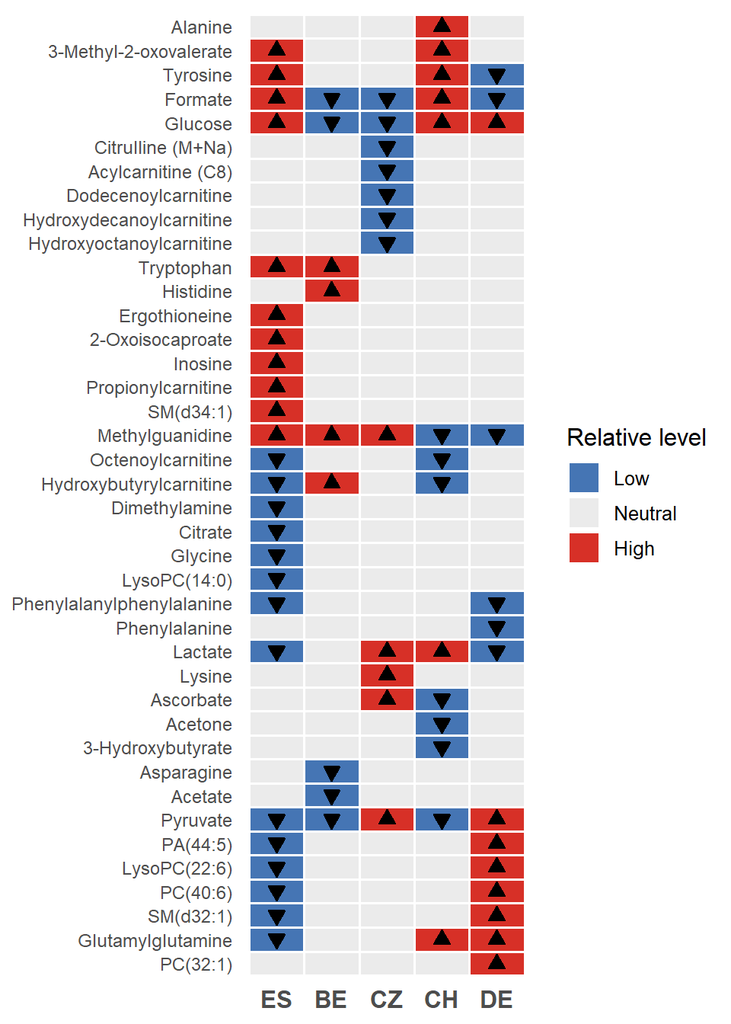

```r
p_emmeans_heatmap <- direction_heatmap(country_effects)
p_emmeans_heatmap <- fix_labels(p_emmeans_heatmap)
p_emmeans_heatmap
```

```r
f <- p_emmeans_heatmap
save(f,file="../results/vegan/figures/F3c_CountryHeatmap.RData")
```

### 4.2.3 Forest plot

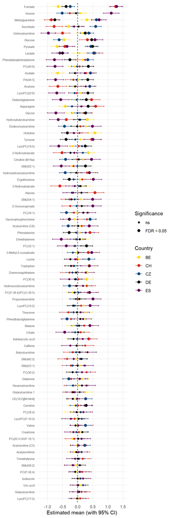

```r
country_effects <- merge(country_effects,dispersion[,c("metabolite","range"),all.x=TRUE,by="metabolite"])

# Define custom country colours
country_colors <- c(
  "BE" = "#FDDA24",  # gold
  "CZ" = "#11457E",  # blue
  "DE" = "#000000",  # black
  "ES" = "#630356",  # purple
  "CH" = "#D52B1E"   # red
)

# order metabolites by mean effect size
forest_df <- country_effects %>%
  group_by(metabolite) %>%
  mutate(range_eff = mean(range)) %>%
  ungroup()

forest_df$metabolite <- factor(
  forest_df$metabolite,
  levels = forest_df %>%
    arrange(range_eff) %>%
    pull(metabolite) %>%
    unique()
)

# Forest plot WITHOUT ANY TEXT LABELS
forest_df <- forest_df %>% mutate(sig = p_adj < 0.05)
p_forest <- ggplot(forest_df,
                   aes(x = emmean,
                       y = metabolite,
                       color = country)) +

  geom_errorbarh(aes(xmin = lower.CL, xmax = upper.CL), height = 0.2) +
  geom_vline(xintercept = 0, linetype = "dashed") +
  geom_point(size = 2.5,aes(shape = sig)) +
  scale_shape_manual(values = c(`FALSE` = 20, `TRUE` = 19),   # 1 = open, 19 = solid
                     labels = c("ns", "FDR < 0.05"),
                     name   = "Significance") +
  scale_color_manual(values = country_colors) +

  theme_minimal() +
  theme(axis.title.y = element_blank(),
        axis.text.y = element_text(size = 6),
        panel.grid.minor = element_blank()) +

  labs(
    x = "Estimated mean (with 95% CI)",
    color = "Country"
  )

p_forest <- fix_labels(p_forest)

p_forest
```

```r
f <- p_forest
save(f,file="../results/vegan/figures/FS_CountryForest.RData")
```

### 4.2.4 Heatmap

```r
df2 <- country_effects_pairwise %>%
  mutate(
    contrast = gsub(" ", "", contrast),   # remove spaces, e.g. "BE-DE"
    signif = p_adj < 0.05
  )

df2$Significance <- ifelse(df2$p_adj<0.001,"***",
                                       ifelse(df2$p_adj<0.01,"**",
                                              ifelse(df2$p_adj<0.05,"*","")))
```

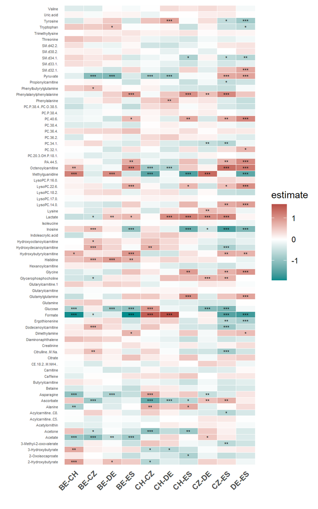

```r
p_pairwise_heatmap <- ggplot(df2, aes(x = contrast, y = Metabolite, fill = estimate)) +
  geom_tile(color = "white") +
  geom_text(aes(label = Significance,vjust=0.6), color = "black", size = 2) +
  scale_fill_gradient2(
    low = "darkcyan", mid = "white", high = "brown", midpoint = 0) +
  theme_minimal() +
  theme(axis.text.y = element_text(size=4),
        axis.text.x = element_text(angle = 45,face="bold",hjust = 1),
        panel.grid = element_blank()) +
  xlab("") + ylab("")

p_pairwise_heatmap
```

### 4.2.5 Network

**Edge list**

```r
edges <- country_effects %>%
  #filter(abs(emmean) > 0.3) %>%
  filter(p_adj<0.05) %>%
  dplyr::select(from = country, to = metabolite,
         emmean = emmean) %>%
  dplyr::mutate(from=as.character(from),
         weight=abs(emmean))

edges$from <- as.character(edges$from)
edges$to   <- as.character(edges$to)
```

**Nodes table**

```r
library(igraph)
library(ggraph)

countries <- as.character(unique(edges$from))
metabs <- as.character(unique(edges$to))

nodes <- data.frame(
  name = c(countries, metabs),
  type = c(rep(TRUE, length(countries)), rep(FALSE, length(metabs))) # TRUE = country, FALSE = metabolite
)
```

**Build igraph object**

```r
g <- graph_from_data_frame(d = edges, vertices = nodes, directed = FALSE)
```

**Visualize**

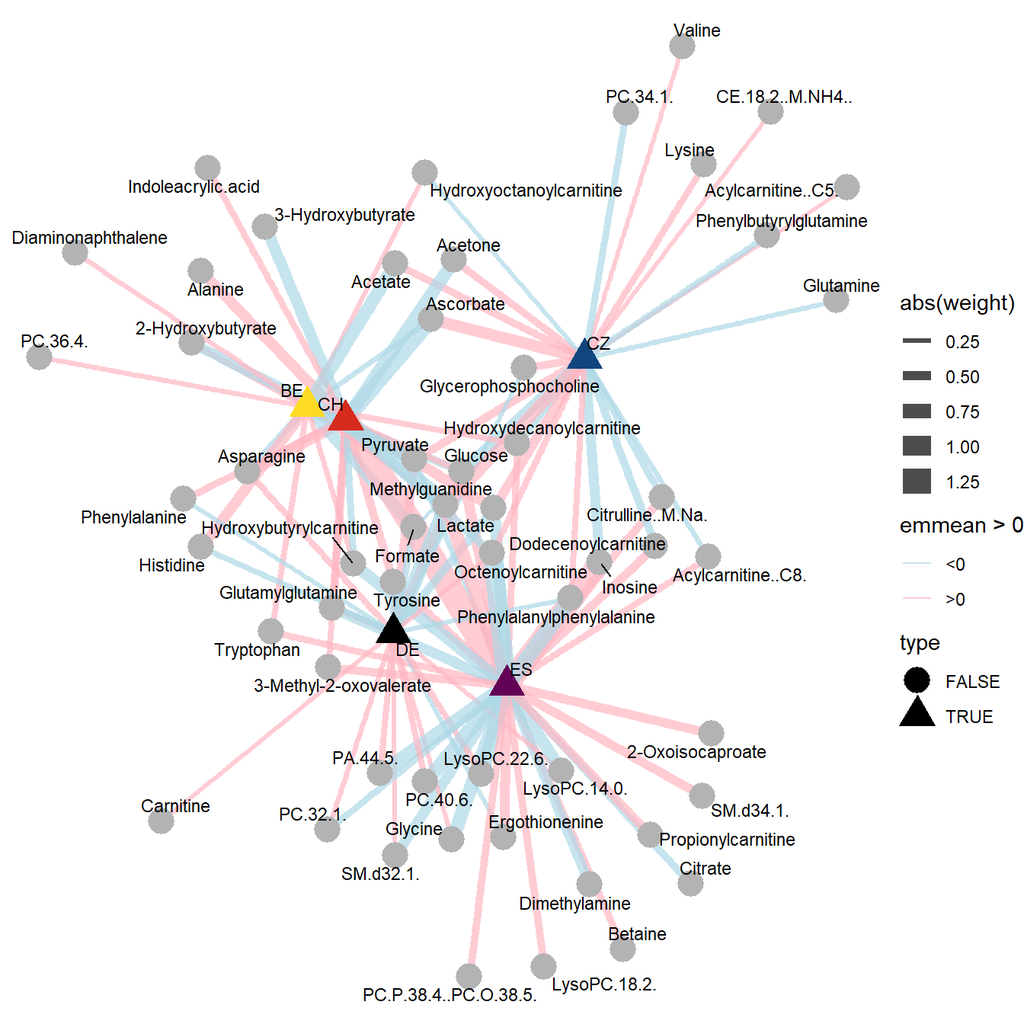

```r
country_colors <- c(
  BE = "#FDDA24",  # gold
  CZ = "#11457E",  # blue
  DE = "#000000",  # black
  ES = "#630356",  # purple
  CH = "#D52B1E"   # red
)

# Assign colors to nodes: countries get their color, metabolites gray
V(g)$color <- ifelse(V(g)$type,
                     country_colors[V(g)$name],
                     "gray70")

set.seed(123)
ggraph(g, layout = "fr") +
  geom_edge_link(aes(width = abs(weight), color = emmean > 0), alpha = 0.7) +
  scale_edge_color_manual(values = c("lightblue", "lightpink"), labels = c("<0", ">0")) +
  geom_node_point(aes(shape=type,color = name), size = 6) +
  scale_color_manual(values = setNames(V(g)$color, V(g)$name)) +  # node colors
  geom_node_text(aes(label = name), repel = TRUE, size = 3) +
  theme_void() +
  guides(color = "none")
```

#### 4.2.5.1 Degree calculation

A country with a high degree has many metabolites significantly associated with it. This can be interpreted in several ways: - strong metabolic distinctiveness - a broad metabolic shift - possibly a strong dietary or cultural metabolic signature - or simply greater statistical power

A high-degree metabolite can indicate: - high cross-country variability - a shared axis of variation

A low-degree metabolite (linked to only 1–2 countries) suggests: - a more country-specific signal - a better candidate as a geographic biomarker

```r
# Calculate degree
deg <- degree(g, mode = "all")

# Add to node dataframe
node_degree_df <- data.frame(
  name = names(deg),
  degree = deg,
  type = V(g)$type
)

# Separate interpretation
country_nodes <- node_degree_df %>% dplyr::filter(type == TRUE)
metabolite_nodes <- node_degree_df %>% dplyr::filter(type == FALSE)

country_nodes %>% arrange(desc(degree))
```

```
   name degree type
ES   ES     33 TRUE
CZ   CZ     24 TRUE
DE   DE     22 TRUE
CH   CH     18 TRUE
BE   BE     15 TRUE
```

```r
metabolite_nodes %>% arrange(desc(degree))
```

```
                                               name degree  type
Formate                                     Formate      5 FALSE
Glucose                                     Glucose      5 FALSE
Methylguanidine                     Methylguanidine      5 FALSE
Pyruvate                                   Pyruvate      5 FALSE
Lactate                                     Lactate      4 FALSE
Octenoylcarnitine                 Octenoylcarnitine      4 FALSE
Ascorbate                                 Ascorbate      3 FALSE
Asparagine                               Asparagine      3 FALSE
Glutamylglutamine                 Glutamylglutamine      3 FALSE
Hydroxybutyrylcarnitine     Hydroxybutyrylcarnitine      3 FALSE
Hydroxydecanoylcarnitine   Hydroxydecanoylcarnitine      3 FALSE
Phenylalanylphenylalanine Phenylalanylphenylalanine      3 FALSE
Tyrosine                                   Tyrosine      3 FALSE
2-Hydroxybutyrate                 2-Hydroxybutyrate      2 FALSE
3-Methyl-2-oxovalerate       3-Methyl-2-oxovalerate      2 FALSE
Acetate                                     Acetate      2 FALSE
Acetone                                     Acetone      2 FALSE
Acylcarnitine..C8.               Acylcarnitine..C8.      2 FALSE
Citrulline..M.Na.                 Citrulline..M.Na.      2 FALSE
Dodecenoylcarnitine             Dodecenoylcarnitine      2 FALSE
Ergothionenine                       Ergothionenine      2 FALSE
Glycerophosphocholine         Glycerophosphocholine      2 FALSE
Glycine                                     Glycine      2 FALSE
Histidine                                 Histidine      2 FALSE
Hydroxyoctanoylcarnitine   Hydroxyoctanoylcarnitine      2 FALSE
Inosine                                     Inosine      2 FALSE
LysoPC.14.0.                           LysoPC.14.0.      2 FALSE
LysoPC.22.6.                           LysoPC.22.6.      2 FALSE
PA.44.5.                                   PA.44.5.      2 FALSE
PC.32.1.                                   PC.32.1.      2 FALSE
PC.40.6.                                   PC.40.6.      2 FALSE
Phenylalanine                         Phenylalanine      2 FALSE
SM.d32.1.                                 SM.d32.1.      2 FALSE
Tryptophan                               Tryptophan      2 FALSE
2-Oxoisocaproate                   2-Oxoisocaproate      1 FALSE
3-Hydroxybutyrate                 3-Hydroxybutyrate      1 FALSE
Acylcarnitine..C5.               Acylcarnitine..C5.      1 FALSE
Alanine                                     Alanine      1 FALSE
Betaine                                     Betaine      1 FALSE
Carnitine                                 Carnitine      1 FALSE
CE.18.2..M.NH4..                   CE.18.2..M.NH4..      1 FALSE
Citrate                                     Citrate      1 FALSE
Diaminonaphthalene               Diaminonaphthalene      1 FALSE
Dimethylamine                         Dimethylamine      1 FALSE
Glutamine                                 Glutamine      1 FALSE
Indoleacrylic.acid               Indoleacrylic.acid      1 FALSE
Lysine                                       Lysine      1 FALSE
LysoPC.18.2.                           LysoPC.18.2.      1 FALSE
PC.34.1.                                   PC.34.1.      1 FALSE
PC.36.4.                                   PC.36.4.      1 FALSE
PC.P.38.4..PC.O.38.5.         PC.P.38.4..PC.O.38.5.      1 FALSE
Phenylbutyrylglutamine       Phenylbutyrylglutamine      1 FALSE
Propionylcarnitine               Propionylcarnitine      1 FALSE
SM.d34.1.                                 SM.d34.1.      1 FALSE
Valine                                       Valine      1 FALSE
```

**Weighted degree** - reflects the cumulative magnitude of associations, not just the number of links.

```r
strength_vals <- strength(g, weights = E(g)$weight)

node_strength_df <- data.frame(
  name = names(strength_vals),
  strength = strength_vals,
  type = V(g)$type
)

# Separate interpretation
country_nodes <- node_strength_df %>% dplyr::filter(type == TRUE)
metabolite_nodes <- node_strength_df %>% dplyr::filter(type == FALSE)

country_nodes %>% arrange(desc(strength))
```

```
   name  strength type
ES   ES 19.298166 TRUE
CH   CH 10.076304 TRUE
CZ   CZ  9.464174 TRUE
DE   DE  7.680800 TRUE
BE   BE  6.278843 TRUE
```

```r
metabolite_nodes %>% arrange(desc(strength))
```

```
                                               name  strength  type
Formate                                     Formate 3.8177192 FALSE
Methylguanidine                     Methylguanidine 3.2521301 FALSE
Glucose                                     Glucose 2.4294153 FALSE
Pyruvate                                   Pyruvate 2.3832436 FALSE
Lactate                                     Lactate 2.1878545 FALSE
Octenoylcarnitine                 Octenoylcarnitine 2.0919567 FALSE
Ascorbate                                 Ascorbate 1.6703369 FALSE
Inosine                                     Inosine 1.6252123 FALSE
Asparagine                               Asparagine 1.3598076 FALSE
Tyrosine                                   Tyrosine 1.3569136 FALSE
Phenylalanylphenylalanine Phenylalanylphenylalanine 1.3562899 FALSE
Hydroxybutyrylcarnitine     Hydroxybutyrylcarnitine 1.3396542 FALSE
Glutamylglutamine                 Glutamylglutamine 1.3025962 FALSE
Hydroxydecanoylcarnitine   Hydroxydecanoylcarnitine 1.1281266 FALSE
PC.40.6.                                   PC.40.6. 1.0996972 FALSE
Acetate                                     Acetate 1.0864912 FALSE
PA.44.5.                                   PA.44.5. 1.0704244 FALSE
Acetone                                     Acetone 1.0555739 FALSE
LysoPC.22.6.                           LysoPC.22.6. 1.0316871 FALSE
Glycine                                     Glycine 0.9826632 FALSE
Dodecenoylcarnitine             Dodecenoylcarnitine 0.9265916 FALSE
Histidine                                 Histidine 0.9137593 FALSE
LysoPC.14.0.                           LysoPC.14.0. 0.8818291 FALSE
2-Hydroxybutyrate                 2-Hydroxybutyrate 0.8679462 FALSE
Citrulline..M.Na.                 Citrulline..M.Na. 0.8575495 FALSE
3-Methyl-2-oxovalerate       3-Methyl-2-oxovalerate 0.8185257 FALSE
SM.d32.1.                                 SM.d32.1. 0.8040908 FALSE
Ergothionenine                       Ergothionenine 0.7981839 FALSE
Tryptophan                               Tryptophan 0.7430657 FALSE
Acylcarnitine..C8.               Acylcarnitine..C8. 0.6900565 FALSE
Glycerophosphocholine         Glycerophosphocholine 0.6889291 FALSE
Phenylalanine                         Phenylalanine 0.6856758 FALSE
PC.32.1.                                   PC.32.1. 0.6726172 FALSE
3-Hydroxybutyrate                 3-Hydroxybutyrate 0.5882741 FALSE
Alanine                                     Alanine 0.5749166 FALSE
Hydroxyoctanoylcarnitine   Hydroxyoctanoylcarnitine 0.5701722 FALSE
Dimethylamine                         Dimethylamine 0.5434955 FALSE
Propionylcarnitine               Propionylcarnitine 0.5055171 FALSE
2-Oxoisocaproate                   2-Oxoisocaproate 0.5020402 FALSE
SM.d34.1.                                 SM.d34.1. 0.4941535 FALSE
Citrate                                     Citrate 0.4273582 FALSE
LysoPC.18.2.                           LysoPC.18.2. 0.4145637 FALSE
Betaine                                     Betaine 0.4072242 FALSE
PC.P.38.4..PC.O.38.5.         PC.P.38.4..PC.O.38.5. 0.3976573 FALSE
PC.34.1.                                   PC.34.1. 0.3709081 FALSE
Lysine                                       Lysine 0.3694360 FALSE
Indoleacrylic.acid               Indoleacrylic.acid 0.3662613 FALSE
Phenylbutyrylglutamine       Phenylbutyrylglutamine 0.3522784 FALSE
Diaminonaphthalene               Diaminonaphthalene 0.3083093 FALSE
PC.36.4.                                   PC.36.4. 0.2942523 FALSE
Glutamine                                 Glutamine 0.2939208 FALSE
Carnitine                                 Carnitine 0.2812460 FALSE
CE.18.2..M.NH4..                   CE.18.2..M.NH4.. 0.2655465 FALSE
Valine                                       Valine 0.2579332 FALSE
Acylcarnitine..C5.               Acylcarnitine..C5. 0.2362085 FALSE
```

#### 4.2.5.2 Top-group assignment

**Based on positive associations**

```r
edges_pos <- edges %>%
  filter(emmean > 0)  # keep only positive associations

g_pos <- graph_from_data_frame(
  d = edges_pos,
  vertices = nodes,
  directed = FALSE)

country_colors <- c(
  BE = "#FDDA24",  # gold
  CZ = "#11457E",  # blue
  DE = "#000000",  # black
  ES = "#630356",  # purple
  CH = "#D52B1E",   # red
  "other" = "gray70"
)

# Assign colors to nodes: countries get their color, metabolites gray
V(g_pos)$color <- ifelse(V(g_pos)$type,
                     country_colors[V(g_pos)$name],
                     "gray70")

top_group <- edges_pos %>%
  dplyr::group_by(to) %>%
  slice_max(order_by = weight, n = 1, with_ties = FALSE) %>%
  dplyr::select(from,to, weight) %>%
  ungroup()

top_group
```

```
# A tibble: 49 × 3
   from  to                     weight
   <chr> <chr>                   <dbl>
 1 BE    2-Hydroxybutyrate       0.351
 2 ES    2-Oxoisocaproate        0.502
 3 ES    3-Methyl-2-oxovalerate  0.465
 4 CZ    Acetate                 0.425
 5 CZ    Acetone                 0.400
 6 CZ    Acylcarnitine..C5.      0.236
 7 ES    Acylcarnitine..C8.      0.381
 8 CH    Alanine                 0.575
 9 CZ    Ascorbate               0.596
10 CH    Asparagine              0.598
# ℹ 39 more rows
```

```r
top_group_viz <- rbind(top_group,
                       data.frame(
                         from=unique(edges$from),
                         to=unique(edges$from),
                         weight=NA))

top_group_viz <- rbind(top_group_viz,
                   data.frame(from="other",
                              to=names(V(g_pos))[!names(V(g_pos)) %in% top_group_viz$to],
                              weight=NA))

membership_df <- data.frame(
  vertex = top_group_viz$to,
  cluster = top_group_viz$from)

membership_df <- membership_df %>% arrange(match(vertex,names(V(g_pos))))
```

```r
country_clusters <- (membership_df %>%
  group_by(cluster) %>%
  summarise(metabolites = paste(unique(vertex), collapse = ", ")))[1:5,]

(membership_df %>%
  group_by(cluster) %>%
  summarise(Number_of_metabolites = length(unique(vertex))-1))[1:5,]
```

```
# A tibble: 5 × 2
  cluster Number_of_metabolites
  <chr>                   <dbl>
1 BE                          6
2 CH                          6
3 CZ                         10
4 DE                          9
5 ES                         18
```

```r
country_clusters
```

```
# A tibble: 5 × 2
  cluster metabolites
  <chr>   <chr>
1 BE      BE, 2-Hydroxybutyrate, Diaminonaphthalene, Histidine, Hydroxybutyrylc…
2 CH      CH, Alanine, Asparagine, Glutamylglutamine, Indoleacrylic.acid, Lacta…
3 CZ      CZ, Acetate, Acetone, Acylcarnitine..C5., Ascorbate, CE.18.2..M.NH4..…
4 DE      DE, Carnitine, Glycine, LysoPC.14.0., LysoPC.22.6., PA.44.5., PC.32.1…
5 ES      ES, 2-Oxoisocaproate, 3-Methyl-2-oxovalerate, Acylcarnitine..C8., Bet…
```

```r
V(g_pos)$fill <- country_colors[membership_df$cluster]
V(g_pos)$color <- country_colors[membership_df$cluster]
```

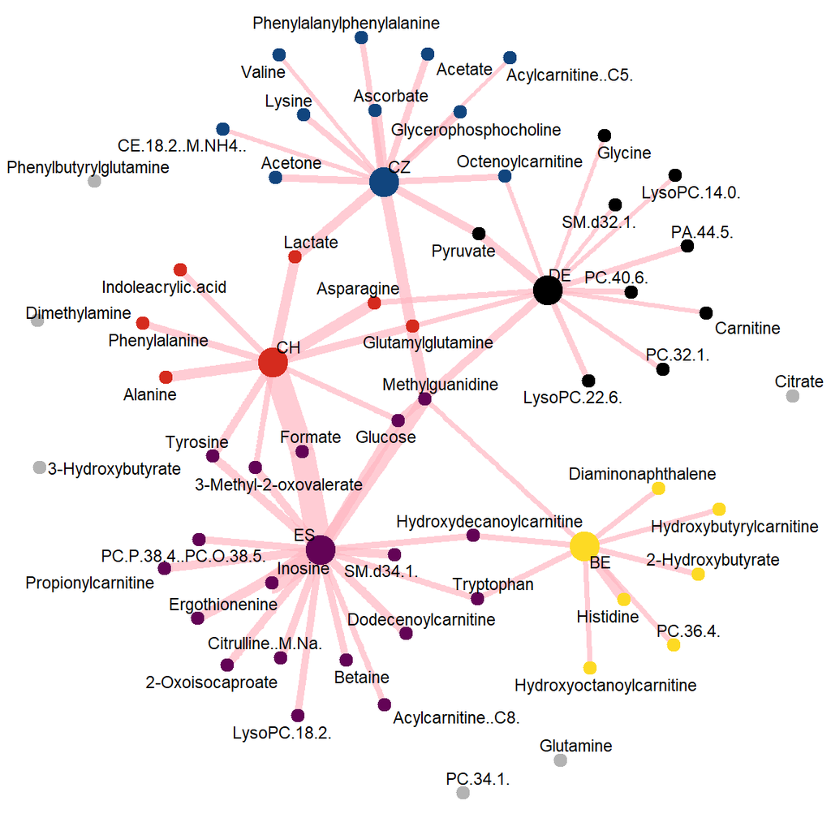

```r
set.seed(123)
p_pos <- ggraph(g_pos, layout = "fr") +
  geom_edge_link(aes(width = abs(weight), color = emmean > 0), alpha = 0.7) +
  scale_edge_color_manual(values = c("lightpink"), labels = c(">0")) +
  geom_node_point(aes(size=type,color = name,fill=name),shape=21,stroke=1.2) +
  scale_color_manual(values = setNames(V(g_pos)$color, V(g_pos)$name))   + # node colors
scale_fill_manual(values = setNames(V(g_pos)$fill, V(g_pos)$name)) +  # node fill
  geom_node_text(aes(label = name), repel = TRUE, size = 3) +
  theme_void() +
  theme(legend.position = "none")

p_pos
```

**Based on negative associations**

```r
edges_neg <- edges %>%
  filter(emmean < 0)  # keep only negative associations

g_neg <- graph_from_data_frame(
  d = edges_neg,
  vertices = nodes,
  directed = FALSE)

country_colors <- c(
  BE = "#FDDA24",  # gold
  CZ = "#11457E",  # blue
  DE = "#000000",  # black
  ES = "#630356",  # purple
  CH = "#D52B1E",   # red
  "other" = "gray70"
)

# Assign colors to nodes: countries get their color, metabolites gray
V(g_neg)$color <- ifelse(V(g_neg)$type,
                     country_colors[V(g_neg)$name],
                     "gray70")

top_group <- edges_neg %>%
  group_by(to) %>%
  slice_max(order_by = weight, n = 1, with_ties = FALSE) %>%
  dplyr::select(from,to, weight) %>%
  ungroup()

top_group
```

```
# A tibble: 38 × 3
   from  to                 weight
   <chr> <chr>               <dbl>
 1 CH    2-Hydroxybutyrate   0.517
 2 CH    3-Hydroxybutyrate   0.588
 3 BE    Acetate             0.662
 4 CH    Acetone             0.656
 5 CZ    Acylcarnitine..C8.  0.309
 6 CH    Ascorbate           0.778
 7 BE    Asparagine          0.414
 8 ES    Citrate             0.427
 9 CZ    Citrulline..M.Na.   0.400
10 ES    Dimethylamine       0.543
# ℹ 28 more rows
```

```r
top_group_viz <- rbind(top_group,
                       data.frame(
                         from=unique(edges$from),
                         to=unique(edges$from),
                         weight=NA))

top_group_viz <- rbind(top_group_viz,
                   data.frame(from="other",
                              to=names(V(g_neg))[!names(V(g_neg)) %in% top_group_viz$to],
                              weight=NA))

membership_df <- data.frame(
  vertex = top_group_viz$to,
  cluster = top_group_viz$from)

membership_df <- membership_df %>% arrange(match(vertex,names(V(g_neg))))
```

```r
country_clusters <- (membership_df %>%
  group_by(cluster) %>%
  summarise(metabolites = paste(unique(vertex), collapse = ", ")))[1:5,]

(membership_df %>%
  group_by(cluster) %>%
  summarise(Number_of_metabolites = length(unique(vertex))-1))[1:5,]
```

```
# A tibble: 5 × 2
  cluster Number_of_metabolites
  <chr>                   <dbl>
1 BE                          4
2 CH                          5
3 CZ                         10
4 DE                          5
5 ES                         14
```

```r
vs_clusters <- (membership_df %>%
  group_by(cluster) %>%
  summarise(metabolites = paste(unique(vertex), collapse = ", ")))[1:5,]

vs_clusters
```

```
# A tibble: 5 × 2
  cluster metabolites
  <chr>   <chr>
1 BE      BE, Acetate, Asparagine, Formate, Pyruvate
2 CH      CH, 2-Hydroxybutyrate, 3-Hydroxybutyrate, Acetone, Ascorbate, Methylg…
3 CZ      CZ, Acylcarnitine..C8., Citrulline..M.Na., Dodecenoylcarnitine, Gluco…
4 DE      DE, Ergothionenine, Glycerophosphocholine, Histidine, Phenylalanine, …
5 ES      ES, Citrate, Dimethylamine, Glutamylglutamine, Glycine, Hydroxybutyry…
```

```r
V(g_neg)$fill <- country_colors[membership_df$cluster]
V(g_neg)$color <- country_colors[membership_df$cluster]
```

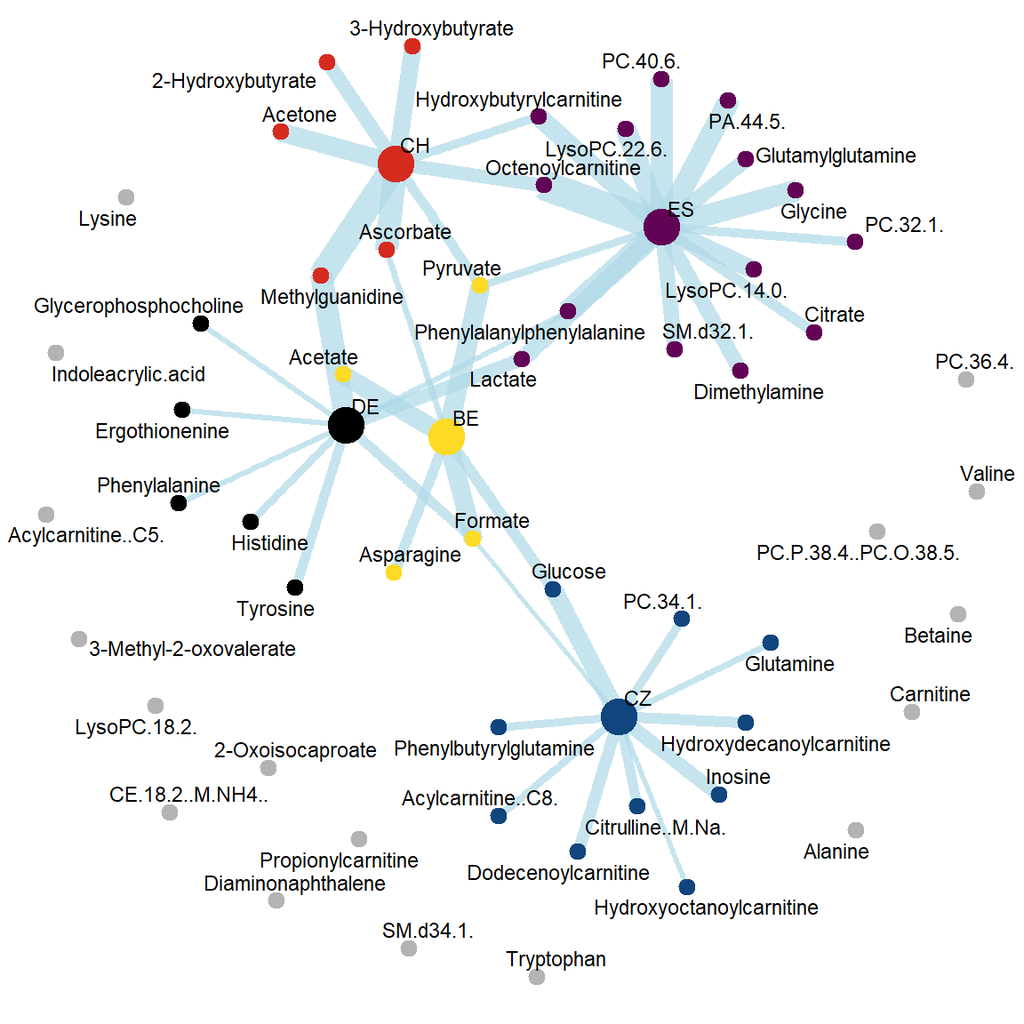

```r
set.seed(123)
p_neg <- ggraph(g_neg, layout = "fr") +
  geom_edge_link(aes(width = abs(weight), color = emmean > 0), alpha = 0.7) +
  scale_edge_color_manual(values = c("lightblue"), labels = c("<0")) +
  geom_node_point(aes(size=type,color = name,fill=name),shape=21,stroke=1.2) +
  scale_color_manual(values = setNames(V(g_neg)$color, V(g_neg)$name))   + # node colors
scale_fill_manual(values = setNames(V(g_neg)$fill, V(g_neg)$name)) +  # node fill
  geom_node_text(aes(label = name), repel = TRUE, size = 3) +
  theme_void() +
  theme(legend.position = "none")

p_neg
```

# 5 Final significant metabolites

```r
list_core <- list()

list_core[["concat_univariate"]] <- unique(concat_significant$metabolite)
```

```r
final_significance <- list_core[["concat_univariate"]]
final_significance
```

```
 [1] "CE.18.2..M.NH4.."          "PC.36.4."
 [3] "PA.44.5."                  "PC.32.1."
 [5] "PC.34.1."                  "PC.40.6."
 [7] "PC.P.38.4..PC.O.38.5."     "SM.d34.1."
 [9] "LysoPC.22.6."              "SM.d32.1."
[11] "Indoleacrylic.acid"        "LysoPC.18.2."
[13] "Dodecenoylcarnitine"       "LysoPC.14.0."
[15] "Acylcarnitine..C8."        "Octenoylcarnitine"
[17] "Hydroxydecanoylcarnitine"  "Acylcarnitine..C5."
[19] "Hydroxyoctanoylcarnitine"  "Phenylalanylphenylalanine"
[21] "Propionylcarnitine"        "Betaine"
[23] "Tryptophan"                "Diaminonaphthalene"
[25] "Hydroxybutyrylcarnitine"   "Ergothionenine"
[27] "Carnitine"                 "Glutamine"
[29] "Phenylbutyrylglutamine"    "Glycerophosphocholine"
[31] "Citrulline..M.Na."         "Glutamylglutamine"
[33] "Formate"                   "Inosine"
[35] "Phenylalanine"             "Histidine"
[37] "Tyrosine"                  "Ascorbate"
[39] "Lactate"                   "Glucose"
[41] "Glycine"                   "Lysine"
[43] "Asparagine"                "Methylguanidine"
[45] "Dimethylamine"             "2-Oxoisocaproate"
[47] "Citrate"                   "Pyruvate"
[49] "3-Hydroxybutyrate"         "Acetone"
[51] "Acetate"                   "Alanine"
[53] "3-Methyl-2-oxovalerate"    "Valine"
[55] "2-Hydroxybutyrate"
```

# 6 Plot for publication

## 6.1 PCA

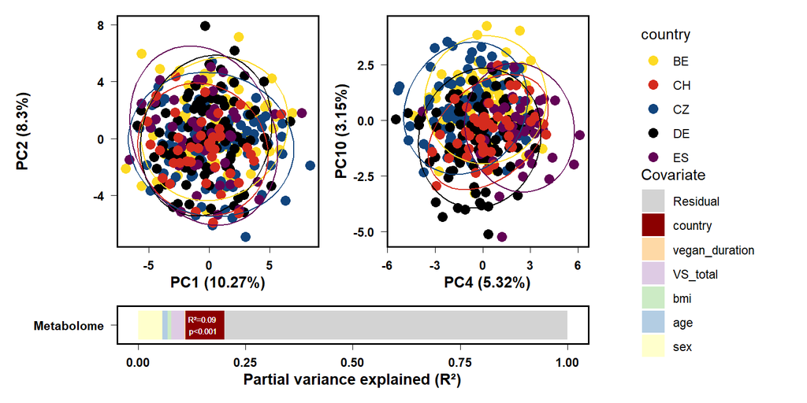

```r
p1 <- p_pca[[1]]
country_leg <- ggpubr::get_legend(p1)
p1 <- p1 + theme(legend.position = "none")

p2 <- p_pca[[4]]
p2 <- p2 + theme(legend.position = "none")

p3 <- p_pca[[2]] +
  geom_text(aes(x=0.15,y=1),label=paste0("R²=",round(p_pca[[3]]$R2[6],2),"\n p<0.001"),size=2,color="white")

factor_leg <- ggpubr::get_legend(p3)
p3 <- p3 + theme(legend.position = "none")

legends <- ggarrange(country_leg, factor_leg, nrow = 2, align = "hv")

layout <- "
AABBDD
AABBDD
AABBDD
CCCCDD
"

# Now plot!
p1 + p2 + p3 + legends +
plot_layout(design = layout, heights = c(2,2,2,1),widths = c(1,1,1,1,1,1))
```

## 6.2 Heatmap

### 6.2.1 Emmeans

```r
concat_significant_df <- concat_significant
concat_significant_df <- concat_significant_df %>%
  dplyr::filter(metabolite %in% final_significance) %>%
  dplyr::arrange(emmean)

heatmap_concat_integrated_df <- concat_integrated_df

# Create a grouping variable for each block of 10 rows

# Calculate the mean for each group
df_grouped <- aggregate(heatmap_concat_integrated_df,
                        by = list(Group = metadata_df$country), FUN = median)
```

LM score

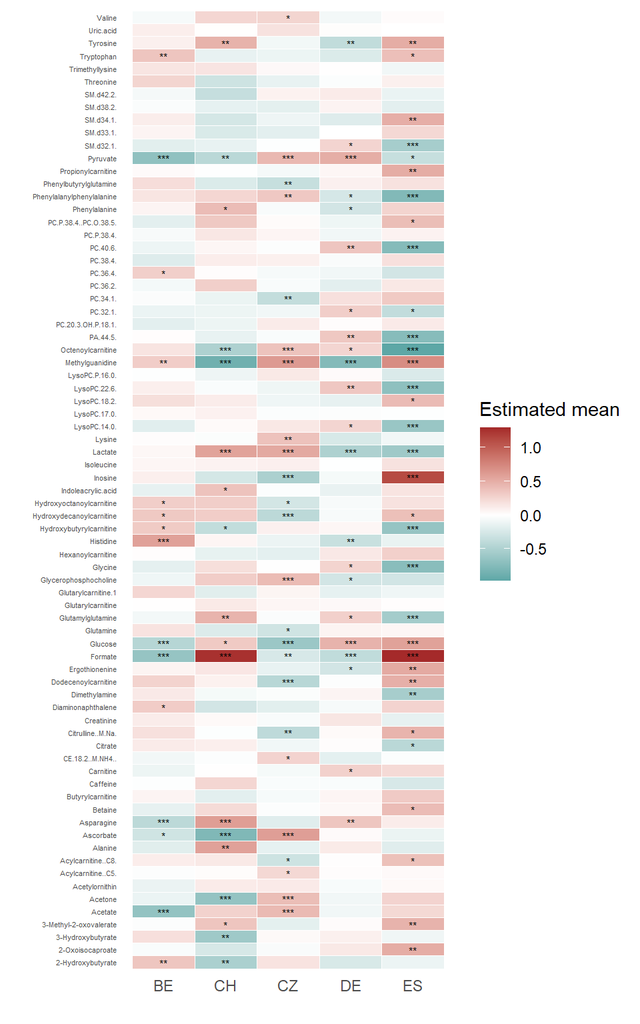

```r
country_effects$Significance <- ifelse(country_effects$p_adj<0.001,"***",
                                       ifelse(country_effects$p_adj<0.01,"**",
                                              ifelse(country_effects$p_adj<0.05,"*","")))

p_heat <- ggplot(country_effects, aes(x = country, y = metabolite, fill = emmean)) +
  geom_tile(color = "white",width=1) +
   geom_text(aes(label = Significance,vjust=0.6), color = "black", size = 2) +  # Add asterisks for significant points
  theme_minimal() +
  theme(axis.title.x = element_text(face = "bold",size = 9),
        axis.text.y = element_text(size=4),
        panel.grid = element_blank()) +
  labs(fill = "Estimated mean") +
  xlab("") +
  ylab("") +
  scale_fill_gradient2(
    low = "darkcyan", mid = "white", high = "brown", midpoint = 0)

p_heat
```

### 6.2.2 Interesting metabolites

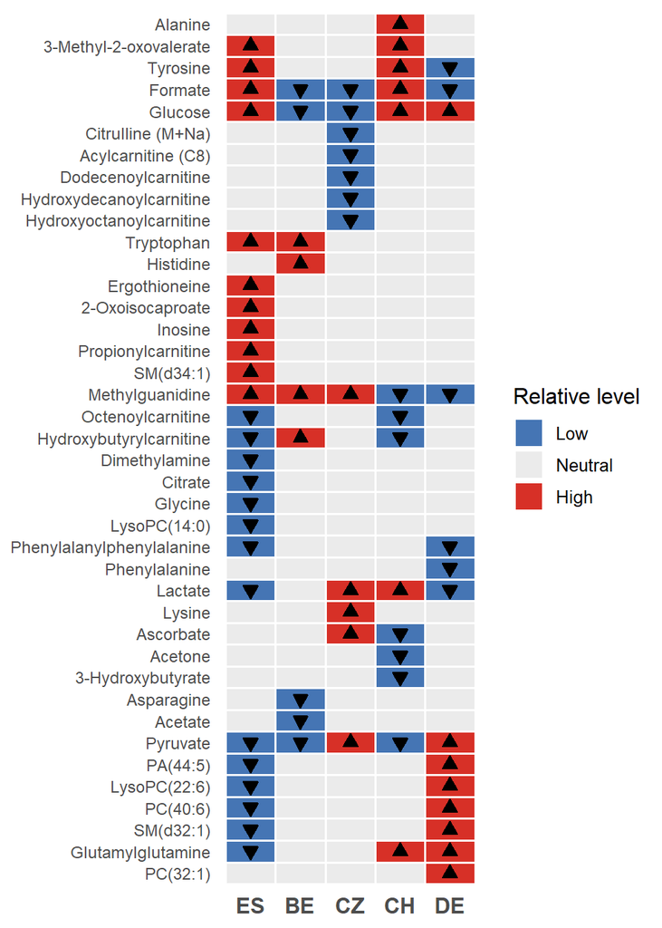

```r
p_emmeans_heatmap
```

```r
fsup1b <- p_emmeans_heatmap
save(fsup1b,file="../results/vegan/figures/fsup1b.RData")
```

### 6.2.3 Pairwise

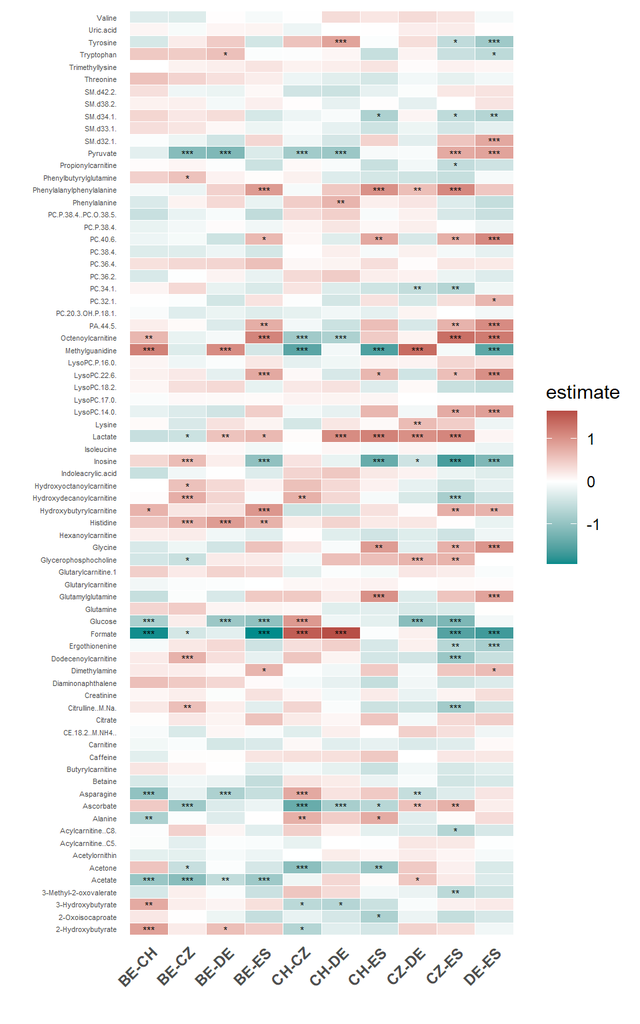

```r
p_pairwise_heatmap
```

## 6.3 Forest plot

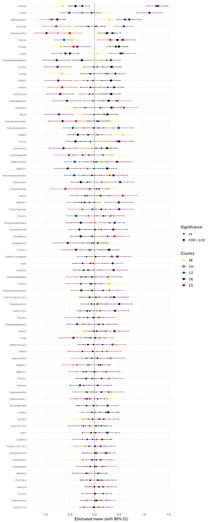

```r
p_forest
```

```r
save(p_forest,file = "../results/vegan/figures/FS1.RData")
```

## 6.4 Network

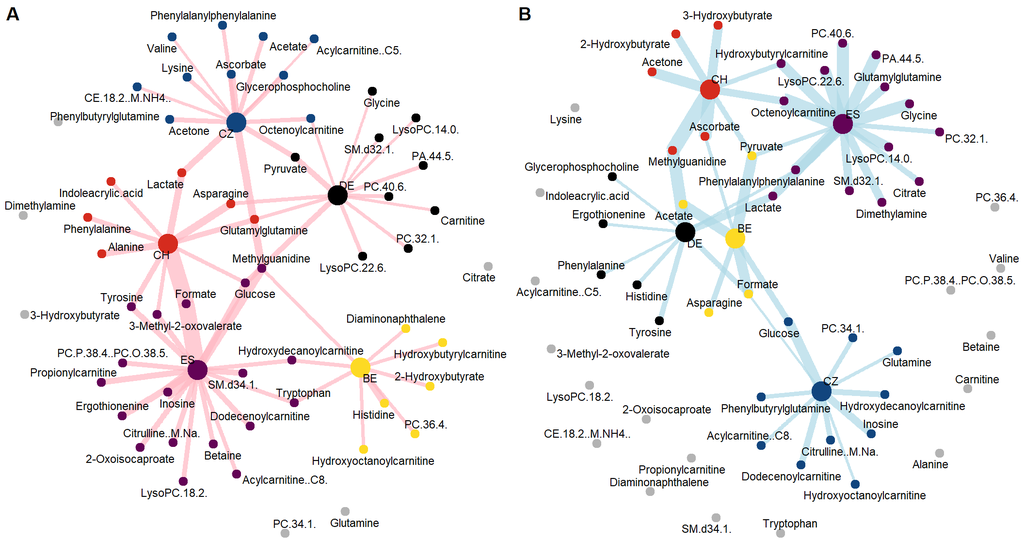

```r
p_net <- ggarrange(p_pos,p_neg,labels = c("A","B"))
p_net
```